# Final

#### BUSINESS PROBLEM: PREDICT THE PRICE OF AIRBNB LISTINGS

Airbnb is an Online home-sharing marketplace for arranging or offering lodging, primarily homestays, or tourism experiences. Since its inception in 2008, Airbnb has seen an enormous growth, with the number of rentals listed on its website growing exponentially each year. Rental Hostings has become very interesting for most households in cities like Singapore which is very small but heavily urbanised. Therefore, being able to accurately value the prices will not only facilitate market transactions by providing valuable guidance for all market participants (be it home owners, visitors, airbnb or its competitors), but also provide useful insights for policy makers and government authorities in understanding the current state of this online marketplace.

The company wants to create an analytical and modelling framework to predict the prices based on the quantitative and qualitative features provided in the dataset.

#### MACHINE LEARNING PROBLEM: USING A REGRESSION MODEL TO PREDICT THE PRICE OF THE HOTEL ROOM

```python
import pandas as pd
import numpy as np
import matplotlib.pyplot as plt
from IPython.core.display import HTML
from sklearn.preprocessing import LabelEncoder,StandardScaler
from statsmodels.stats.outliers_influence import variance_inflation_factor
from datetime import date
from sklearn.model_selection import train_test_split,GridSearchCV
from sklearn.linear_model import LinearRegression,Lasso
from sklearn.metrics import mean_squared_error,r2_score
from mlxtend.plotting import plot_learning_curves
from sklearn.ensemble import RandomForestRegressor
from sklearn.svm import SVR
from xgboost import XGBRegressor
import seaborn as sns
import warnings
warnings.filterwarnings('ignore')
%matplotlib inline
```

```python
def get_NaN_info(data):
    return pd.DataFrame(data.dtypes,columns=['Type']).merge(pd.DataFrame(data.isnull().sum(),columns=['Total Cnt of NaN']).merge(pd.DataFrame(data.isnull().sum()/len(data)*100,columns=['Total % of NaN']),left_index=True,right_index=True),left_index=True,right_index=True).sort_values('Total % of NaN',ascending=False)

def get_index(data,col,value):
    return (data[data[col]>value].index)

def inspect_data(data):
    return pd.DataFrame({"Data Type":data.dtypes,"No of Levels":data.apply(lambda x: x.nunique(),axis=0),"% of Unique Levels":data.apply(lambda x: 100*x.nunique()/len(x),axis=0), "Levels":data.apply(lambda x: str(x.unique()),axis=0)}).sort_values("% of Unique Levels", ascending=False)

def get_split_value(string):
    return string.replace('[]','').replace('{','').replace('}','').replace('"','').split(',')

def get_aminities_cnt(data):
    return data['amenities'].apply(lambda x:get_split_value(x)).apply(lambda x:pd.DataFrame(x).values if len(x)==1 else x).apply(lambda x:len(x) if x else 0)

def get_box_plot(data,col1,col2):
    sns.boxplot(data[col1],data[col2])
    plt.show()

def get_dist_plot(data,col):
    sns.distplot(data[col])
    plt.show()

def get_scatter_plot(data,col1,col2):
    plt.scatter(data[col1],data[col2])
    plt.show()

def get_joint_plot(data,col1,col2):
    sns.jointplot(data[col1],data[col2])
    plt.show()

def get_heatmap(data):
    fig, ax = plt.subplots(figsize=(50,50))
    sns.heatmap(data.corr(),linewidths=0.01,annot=True,ax=ax)
    plt.show()

#Get leves and NaN information combined
def get_levels_NaNs_combined_info(data,cnt):
    return (inspect_data(data[get_NaN_info(data).head(cnt).index]).sort_index()).merge((get_NaN_info(data).head(cnt)).iloc[:,[1,2]],left_index=True,right_index=True)

def get_corr_vals_of_col(data,col):
    corr=data.corr()[col]
    return corr[np.argsort(corr, axis=0)[::-1]].sort_values(ascending=False)

def two_level_label_encode(data):
    label_encoder=LabelEncoder()
    two_Level_features=inspect_data(data)[inspect_data(data)['No of Levels']==2].index
    for x in two_Level_features.values:
        data[x]=label_encoder.fit_transform(data[x])
    return data

def club_groups(data,col,from_grp_values,to_group):
    indexes=data[data[col].isin(from_grp_values)].index
    if len(indexes):
        data.loc[indexes,col]=to_group
    return data

def impute_string(data,grp_cols,null_col,value):
    indexes=data[data.groupby(grp_cols)[null_col].transform(lambda x:x).isnull()].index
    if len(indexes):
        data.loc[indexes,null_col]=value
    return data

def impute_train_mode(train,cols):
    for x in cols:
        train[x].fillna(train[x].mode()[0],inplace=True)
    return train

def impute_test_mode(train,test,cols):
    for x in cols:
        test[x].fillna(train[x].mode()[0],inplace=True)
    return test

def drop_cols(data,drop_cols):
    data.drop(drop_cols,axis=1,inplace=True)
    return data

#This function will pass the desired group_cols and mean_col on which the NaN need to be imputed to below function
def start_train_impute_NaN(train,grp_cols,mean_col):
    num_of_grp_vars=len(grp_cols)

    for i in range(num_of_grp_vars):
        group_cols=grp_cols[0:num_of_grp_vars-i]
        train=impute_train_NaN_with_train_mean(train,group_cols,mean_col)
        if train[mean_col].isnull().sum():
            continue
        else:
            break
    return train

#This function will group the group_cols and apply mean() on the mean_col and impute NaN with it
def impute_train_NaN_with_train_mean(train,grp_cols,mean_col):
    train[mean_col]=train.groupby(grp_cols)[mean_col].transform(lambda x: x.fillna(np.round(x.mean())))
    return train

#This function will pass the desired group_cols and mean_col on which the NaN need to be imputed to above function for test_data
def start_test_impute_NaN(train,test,grp_cols,mean_col):
    num_of_grp_vars=len(grp_cols)

    for i in range(num_of_grp_vars):
        group_cols=grp_cols[0:num_of_grp_vars-i]
        test=impute_test_NaN_with_train_mean(train,test,group_cols,mean_col)
        if test[mean_col].isnull().sum():
            continue
        else:
            break
    return test

#This function will group the group_cols and impute train mean() on the mean_col of test wherever NaN are present in test data
def impute_test_NaN_with_train_mean(train,test,grp_cols,mean_col):

    train_grp   = train.groupby(grp_cols)[mean_col].mean()
    test_merged = test.merge(train_grp, on=grp_cols, suffixes=['_test', '_train'],how='left')
    #Create dictionary of corresponding columns
    test_cols   = [col for col in test_merged.columns if 'test' in col]
    train_cols  = [col for col in test_merged.columns if 'train' in col]
    dict_cols   = dict(zip(test_cols, train_cols))

    for test, train in dict_cols.items():
        test_merged[test] = np.where(test_merged[test].isnull(),test_merged[train],test_merged[test])
    # Clean up dataframe
    test_merged.drop(train_cols, axis=1, inplace=True)
    test_merged.columns = test_merged.columns.str.replace('_test', '')
    return test_merged

#This below function does all the preprocess necessary for this problem. Like dropping cols, imputing NaN,
#creating new categories by grouping existing categies, calculating the number of categories in a particular row for an
#amenities column.
def preprocess_train(X_trn,y_trn):
    y_trn['price']=np.log(y_trn['price']+1)
    X_trn['amenities']=get_aminities_cnt(X_trn)
    mean_col_grp_cols={'cleaning_fee':['neighbourhood_group','property_type','room_type'],\
                       'security_deposit':['neighbourhood_group','property_type','room_type','minimum_nights'],\
                       'bedrooms':['neighbourhood_group','property_type','room_type'],\
                       'beds':['property_type','room_type','bedrooms'],\
                       'bathrooms':['property_type','room_type','bedrooms']}

    for mean_col,grp_cols in mean_col_grp_cols.items():
        X_trn=start_train_impute_NaN(X_trn,grp_cols,mean_col)

    to_grp_from_grp_values={'strict':['strict_14_with_grace_period','super_strict_30', 'super_strict_60', 'strict'],\
                            'Sofa bed':['Futon', 'Pull-out Sofa', 'Couch', 'Airbed']}
    club_grp_col=['cancellation_policy','bed_type']
    i=0
    for to_group,from_grp_values in to_grp_from_grp_values.items():
        X_trn=club_groups(X_trn,club_grp_col[i],from_grp_values,to_group)
        i+=1

    X_trn=two_level_label_encode(X_trn)
    return X_trn , y_trn


def preprocess_test(X_trn,X_tst,y_tst):
    y_tst['price']=np.log(y_tst['price']+1)
    X_tst['amenities']=get_aminities_cnt(X_tst)
    mean_col_grp_cols={'cleaning_fee':['neighbourhood_group','property_type','room_type'],\
                       'security_deposit':['neighbourhood_group','property_type','room_type','minimum_nights'],\
                       'bedrooms':['neighbourhood_group','property_type','room_type'],\
                       'beds':['property_type','room_type','bedrooms'],\
                       'bathrooms':['property_type','room_type','bedrooms']}

    for mean_col,grp_cols in mean_col_grp_cols.items():
        X_tst=start_test_impute_NaN(X_trn,X_tst,grp_cols,mean_col)

    to_grp_from_grp_values={'strict':['strict_14_with_grace_period','super_strict_30', 'super_strict_60', 'strict'],\
                            'Sofa bed':['Futon', 'Pull-out Sofa', 'Couch', 'Airbed']}
    club_grp_col=['cancellation_policy','bed_type']
    i=0
    for to_group,from_grp_values in to_grp_from_grp_values.items():
        X_tst=club_groups(X_tst,club_grp_col[i],from_grp_values,to_group)
        i+=1

    X_tst=two_level_label_encode(X_tst)
    X_tst.index=y_tst.index
    return X_tst , y_tst

#Tries to find all the outlier values through the Z_scores of that column and try to remove if the value of Z_score for that
#row is greter than threshold, here we took 3.5
def get_index_of_possible_outliers(X_trn,X_tst,y_trn):

    scaler=StandardScaler()
    scaled_features_X_trn = scaler.fit_transform(X_trn)
    scaled_features_X_trn_df = pd.DataFrame(scaled_features_X_trn, index=X_trn.index, columns=X_trn.columns)

    scaled_features_X_tst = scaler.transform(X_tst)
    scaled_features_X_tst_df = pd.DataFrame(scaled_features_X_tst, index=X_tst.index, columns=X_tst.columns)

    scaled_features_y_trn = scaler.fit_transform(y_trn)
    scaled_features_y_trn_df = pd.DataFrame(scaled_features_y_trn, index=y_trn.index, columns=y_trn.columns)

    drop_index=list(scaled_features_y_trn_df[(scaled_features_y_trn_df['price']>=3.5)|(scaled_features_y_trn_df['price']<=-3.5)].index)
    drop_index_tst=[]

    for col in scaled_features_X_trn_df.columns:

        indexes=list(scaled_features_X_trn_df[(scaled_features_X_trn_df[col]>=3.5)|(scaled_features_X_trn_df[col]<=-3.5)].index)
        drop_index.extend(indexes)
        drop_index=sorted(list(np.unique(drop_index)))
        indexes=list(scaled_features_X_tst_df[(scaled_features_X_tst_df[col]>=3.5)|(scaled_features_X_tst_df[col]<=-3.5)].index)

        drop_index_tst.extend(indexes)
        drop_index_tst=sorted(list(np.unique(drop_index_tst)))

    return(drop_index,drop_index_tst)
```

```python
#Read File:
full_data=pd.read_csv('listings.csv')
full_data.shape
```

```
(7675, 67)
```

```python
X = full_data.copy().drop("price",axis=1)
y = full_data.filter(["price"],axis=1)
X_train, X_val, y_train, y_val = train_test_split(X, y, test_size=0.20,random_state=1)
X_train.shape, X_val.shape, y_train.shape, y_val.shape
```

```
((6140, 66), (1535, 66), (6140, 1), (1535, 1))
```

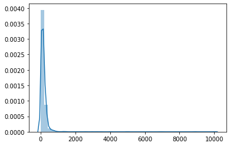

```python
#Its not normally distribute and also it shows that it it right skewed
get_dist_plot(y_train,['price'])
```

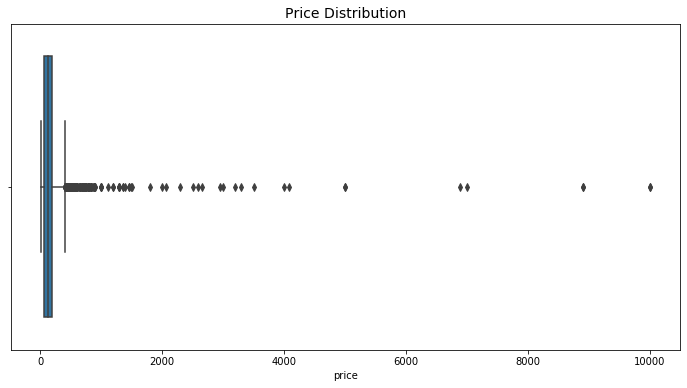

```python
plt.figure(figsize = (12, 6))
sns.boxplot(x=y_train["price"])
plt.title('Price Distribution', fontsize=14)
plt.show()
```

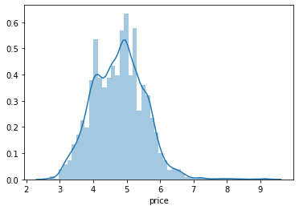

```python
#Lets see if a log tranformation works
sns.distplot(np.log(y_train['price']+1))
```

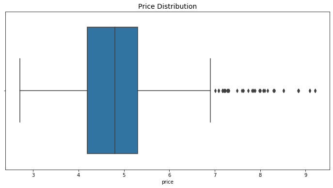

```python
plt.figure(figsize = (12, 6))
sns.boxplot(x=np.log(y_train["price"]+1))
plt.title('Price Distribution', fontsize=14)
plt.show()
```

```python
pd.set_option('display.max_rows', None)
```

```python
#Displays total NaN count and % of NaN values
get_NaN_info(X_train)
```

|  | Type | Total Cnt of NaN | Total % of NaN |
| --- | --- | --- | --- |
| host_acceptance_rate | float64 | 6140 | 100.000000 |
| thumbnail_url | float64 | 6140 | 100.000000 |
| medium_url | float64 | 6140 | 100.000000 |
| jurisdiction_names | float64 | 6140 | 100.000000 |
| xl_picture_url | float64 | 6140 | 100.000000 |
| license | object | 6136 | 99.934853 |
| square_feet | float64 | 6103 | 99.397394 |
| state | object | 5615 | 91.449511 |
| review_scores_rating | float64 | 2210 | 35.993485 |
| reviews_per_month | float64 | 2103 | 34.250814 |
| security_deposit | float64 | 1838 | 29.934853 |
| cleaning_fee | float64 | 1657 | 26.986971 |
| host_response_time | object | 1111 | 18.094463 |
| host_response_rate | float64 | 1111 | 18.094463 |
| zipcode | object | 661 | 10.765472 |
| market | object | 76 | 1.237785 |
| city | object | 64 | 1.042345 |
| host_location | object | 13 | 0.211726 |
| beds | float64 | 9 | 0.146580 |
| neighbourhood | object | 4 | 0.065147 |
| host_since | object | 4 | 0.065147 |
| bathrooms | float64 | 4 | 0.065147 |
| bedrooms | float64 | 1 | 0.016287 |
| host_name | object | 1 | 0.016287 |
| host_has_profile_pic | object | 1 | 0.016287 |
| name | object | 1 | 0.016287 |
| host_identity_verified | object | 1 | 0.016287 |
| host_is_superhost | object | 1 | 0.016287 |
| host_thumbnail_url | object | 1 | 0.016287 |
| host_picture_url | object | 1 | 0.016287 |
| maximum_nights | int64 | 0 | 0.000000 |
| is_business_travel_ready | object | 0 | 0.000000 |
| guests_included | int64 | 0 | 0.000000 |
| extra_people | int64 | 0 | 0.000000 |
| minimum_nights | int64 | 0 | 0.000000 |
| has_availability | object | 0 | 0.000000 |
| requires_license | object | 0 | 0.000000 |
| number_of_reviews | int64 | 0 | 0.000000 |
| number_of_reviews_ltm | int64 | 0 | 0.000000 |
| calculated_host_listings_count | int64 | 0 | 0.000000 |
| cancellation_policy | object | 0 | 0.000000 |
| require_guest_profile_picture | object | 0 | 0.000000 |
| require_guest_phone_verification | object | 0 | 0.000000 |
| instant_bookable | object | 0 | 0.000000 |
| id | int64 | 0 | 0.000000 |
| amenities | object | 0 | 0.000000 |
| neighbourhood_group | object | 0 | 0.000000 |
| scrape_id | int64 | 0 | 0.000000 |
| last_scraped | int64 | 0 | 0.000000 |
| experiences_offered | object | 0 | 0.000000 |
| picture_url | object | 0 | 0.000000 |
| host_id | int64 | 0 | 0.000000 |
| host_url | object | 0 | 0.000000 |
| host_verifications | object | 0 | 0.000000 |
| street | object | 0 | 0.000000 |
| smart_location | object | 0 | 0.000000 |
| bed_type | object | 0 | 0.000000 |
| country_code | object | 0 | 0.000000 |
| listing_url | object | 0 | 0.000000 |
| latitude | float64 | 0 | 0.000000 |
| longitude | float64 | 0 | 0.000000 |
| is_location_exact | object | 0 | 0.000000 |
| property_type | object | 0 | 0.000000 |
| room_type | object | 0 | 0.000000 |
| accommodates | int64 | 0 | 0.000000 |
| country | object | 0 | 0.000000 |

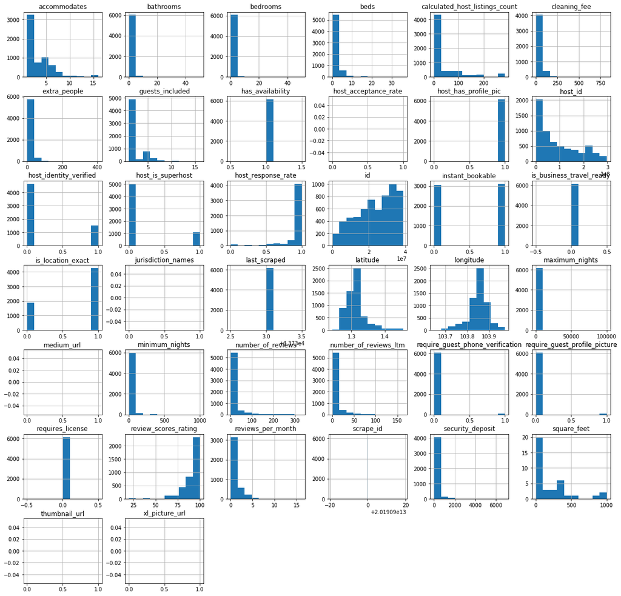

```python
# Replacing columns with f/t with 0/1 and Plotting the distribution of numerical and boolean categories
X_train.replace({'f': 0, 't': 1}).hist(figsize=(20,20))
plt.show()
```

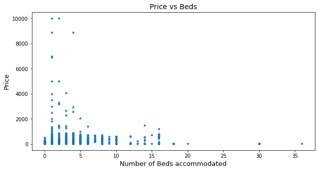

```python
plt.figure(figsize=(10,5))
plt.scatter(X_train['beds'], y_train['price'], marker = '.')
plt.title('Price vs Beds', fontsize=14)
plt.xlabel('Number of Beds accommodated', fontsize=13)
plt.ylabel('Price', fontsize=13)
plt.show()
```

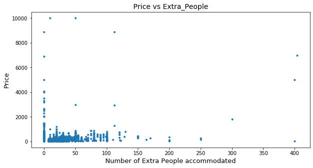

```python
plt.figure(figsize=(10,5))
plt.scatter(X_train['extra_people'], y_train['price'], marker = '.')
plt.title('Price vs Extra_People', fontsize=14)
plt.xlabel('Number of Extra People accommodated', fontsize=13)
plt.ylabel('Price', fontsize=13)
plt.show()
```

```python
get_NaN_info(X_train)
```

|  | Type | Total Cnt of NaN | Total % of NaN |
| --- | --- | --- | --- |
| host_acceptance_rate | float64 | 6140 | 100.000000 |
| thumbnail_url | float64 | 6140 | 100.000000 |
| medium_url | float64 | 6140 | 100.000000 |
| jurisdiction_names | float64 | 6140 | 100.000000 |
| xl_picture_url | float64 | 6140 | 100.000000 |
| license | object | 6136 | 99.934853 |
| square_feet | float64 | 6103 | 99.397394 |
| state | object | 5615 | 91.449511 |
| review_scores_rating | float64 | 2210 | 35.993485 |
| reviews_per_month | float64 | 2103 | 34.250814 |
| security_deposit | float64 | 1838 | 29.934853 |
| cleaning_fee | float64 | 1657 | 26.986971 |
| host_response_time | object | 1111 | 18.094463 |
| host_response_rate | float64 | 1111 | 18.094463 |
| zipcode | object | 661 | 10.765472 |
| market | object | 76 | 1.237785 |
| city | object | 64 | 1.042345 |
| host_location | object | 13 | 0.211726 |
| beds | float64 | 9 | 0.146580 |
| neighbourhood | object | 4 | 0.065147 |
| host_since | object | 4 | 0.065147 |
| bathrooms | float64 | 4 | 0.065147 |
| bedrooms | float64 | 1 | 0.016287 |
| host_name | object | 1 | 0.016287 |
| host_has_profile_pic | object | 1 | 0.016287 |
| name | object | 1 | 0.016287 |
| host_identity_verified | object | 1 | 0.016287 |
| host_is_superhost | object | 1 | 0.016287 |
| host_thumbnail_url | object | 1 | 0.016287 |
| host_picture_url | object | 1 | 0.016287 |
| maximum_nights | int64 | 0 | 0.000000 |
| is_business_travel_ready | object | 0 | 0.000000 |
| guests_included | int64 | 0 | 0.000000 |
| extra_people | int64 | 0 | 0.000000 |
| minimum_nights | int64 | 0 | 0.000000 |
| has_availability | object | 0 | 0.000000 |
| requires_license | object | 0 | 0.000000 |
| number_of_reviews | int64 | 0 | 0.000000 |
| number_of_reviews_ltm | int64 | 0 | 0.000000 |
| calculated_host_listings_count | int64 | 0 | 0.000000 |
| cancellation_policy | object | 0 | 0.000000 |
| require_guest_profile_picture | object | 0 | 0.000000 |
| require_guest_phone_verification | object | 0 | 0.000000 |
| instant_bookable | object | 0 | 0.000000 |
| id | int64 | 0 | 0.000000 |
| amenities | object | 0 | 0.000000 |
| neighbourhood_group | object | 0 | 0.000000 |
| scrape_id | int64 | 0 | 0.000000 |
| last_scraped | int64 | 0 | 0.000000 |
| experiences_offered | object | 0 | 0.000000 |
| picture_url | object | 0 | 0.000000 |
| host_id | int64 | 0 | 0.000000 |
| host_url | object | 0 | 0.000000 |
| host_verifications | object | 0 | 0.000000 |
| street | object | 0 | 0.000000 |
| smart_location | object | 0 | 0.000000 |
| bed_type | object | 0 | 0.000000 |
| country_code | object | 0 | 0.000000 |
| listing_url | object | 0 | 0.000000 |
| latitude | float64 | 0 | 0.000000 |
| longitude | float64 | 0 | 0.000000 |
| is_location_exact | object | 0 | 0.000000 |
| property_type | object | 0 | 0.000000 |
| room_type | object | 0 | 0.000000 |
| accommodates | int64 | 0 | 0.000000 |
| country | object | 0 | 0.000000 |

```python
X_train.shape,y_train.shape
```

```
((6140, 66), (6140, 1))
```

```python
# Converting to datetime
X_train.host_since = pd.to_datetime(X_train.host_since, format="%Y/%m/%d", errors='coerce')
X_train.host_since

X_train11 = X_train[X_train['host_since'].notnull()]
y_train11 = y_train[X_train['host_since'].notnull()]
X_train=X_train11.copy()
y_train=y_train11.copy()
# Calculating the number of days
X_train['today'] = date.today().strftime("%Y-%m-%d")
X_train['today'] = pd.to_datetime(X_train.today)
X_train['host_days_active'] = (X_train.today - X_train.host_since).astype('timedelta64[D]')

#drop the column created and host_since is now created as host_days_active
X_train.drop(['today','host_since'], axis=1, inplace=True)


# Converting to datetime
X_val.host_since = pd.to_datetime(X_val.host_since, format="%Y/%m/%d", errors='coerce')
X_val.host_since
X_val = X_val[X_val['host_since'].notnull()]

# Calculating the number of days
X_val['today'] = str(date.today().strftime("%Y-%m-%d"))
X_val['today'] = pd.to_datetime(X_val.today)
X_val['host_days_active'] = (X_val.today - X_val.host_since).astype('timedelta64[D]')


#drop the column created and host_since is now created as host_days_active
X_val.drop(['today','host_since'], axis=1, inplace=True)
```

```python
#Finding the % of Unique levels in each column
inspect_data(X_train)
```

|  | Data Type | No of Levels | % of Unique Levels | Levels |
| --- | --- | --- | --- | --- |
| id | int64 | 6130 | 100.000000 | [23130011 11747584 19351097 ... 25428764 39095... |
| listing_url | object | 6130 | 100.000000 | ['https://www.airbnb.com/rooms/23130011'\n 'ht... |
| name | object | 5834 | 95.171289 | ["Rachel's House by the SEA Near MRT. 圣淘沙旁 近地铁... |
| picture_url | object | 5732 | 93.507341 | ['https://a0.muscache.com/im/pictures/a6045542... |
| amenities | object | 4777 | 77.928222 | ['{TV,"Cable TV",Wifi,"Air conditioning",Pool,... |
| longitude | float64 | 4535 | 73.980424 | [103.81331 103.78763000000001 103.75644 ... 10... |
| latitude | float64 | 4149 | 67.683524 | [1.26983 1.30474 1.31467 ... 1.34985 1.2798 1.... |
| host_id | int64 | 2226 | 36.313214 | [171890055 62503713 66406177 ... 20785714 1356... |
| host_url | object | 2226 | 36.313214 | ['https://www.airbnb.com/users/show/171890055'... |
| host_thumbnail_url | object | 2217 | 36.166395 | ['https://a0.muscache.com/im/pictures/user/602... |
| host_picture_url | object | 2217 | 36.166395 | ['https://a0.muscache.com/im/pictures/user/602... |
| zipcode | object | 1880 | 30.668842 | ['98837' '138638' '128021' ... '249045' '11941... |
| host_name | object | 1551 | 25.301794 | ['Gigy' 'Vincent' 'Jay' ... 'Mukesh' 'Yock Lia... |
| host_days_active | float64 | 1460 | 23.817292 | [635.0 1331.0 1302.0 ... 1888.0 2047.0 1901.0] |
| reviews_per_month | float64 | 501 | 8.172920 | [3.4 2.24 0.98 nan 1.7 3.2 0.14 0.43 0.21 4.69... |
| number_of_reviews | int64 | 195 | 3.181077 | [67 93 25 0 63 78 1 20 2 10 5 6 8 52 3 31 4 11... |
| host_location | object | 193 | 3.148450 | ['Singapore, Singapore' 'Singapore' 'SG'\n 'In... |
| host_verifications | object | 173 | 2.822186 | ["['email', 'phone', 'zhima_selfie']"\n "['ema... |
| security_deposit | float64 | 127 | 2.071778 | [300.0 200.0 0.0 150.0 201.0 nan 250.0 140.0 1... |
| cleaning_fee | float64 | 109 | 1.778140 | [60.0 50.0 80.0 20.0 0.0 70.0 nan 100.0 35.0 3... |
| maximum_nights | int64 | 107 | 1.745514 | [90 1124 1125 360 180 365 399 400 31 27 730 10... |
| street | object | 85 | 1.386623 | ['Singapore, Singapore' 'SG, Singapore' 'Singa... |
| number_of_reviews_ltm | int64 | 84 | 1.370310 | [37 4 3 0 19 1 2 10 5 8 31 6 24 57 17 51 14 42... |
| extra_people | int64 | 78 | 1.272431 | [40 0 30 50 21 10 20 42 7 29 22 39 35 41 15 45... |
| minimum_nights | int64 | 67 | 1.092985 | [3 30 60 2 90 1 18 7 5 20 4 14 180 6 28 29 183... |
| host_response_rate | float64 | 56 | 0.913540 | [1.0 0.8 0.92 0.4 nan 0.63 0.98 0.97 0.0 0.9 0... |
| calculated_host_listings_count | int64 | 53 | 0.864600 | [1 285 42 2 5 23 7 43 84 19 126 16 4 8 38 159 ... |
| review_scores_rating | float64 | 46 | 0.750408 | [99.0 96.0 98.0 nan 97.0 86.0 100.0 94.0 93.0 ... |
| state | object | 46 | 0.750408 | [nan 'Singapore' 'Sg' 'boon keng' 'Singapòre' ... |
| neighbourhood | object | 42 | 0.685155 | ['Bukit Merah' 'Queenstown' 'Clementi' 'Centra... |
| smart_location | object | 38 | 0.619902 | ['Singapore' 'SG, Singapore' '*, Singapore' 'J... |
| city | object | 37 | 0.603589 | ['Singapore' nan '*' 'Jurong' '新加坡' 'Bedok' 'S... |
| bathrooms | float64 | 27 | 0.440457 | [2.0 1.0 1.5 8.0 3.0 4.0 50.0 2.5 8.5 5.0 7.0 ... |
| property_type | object | 24 | 0.391517 | ['Apartment' 'Loft' 'Condominium' 'Bed and bre... |
| beds | float64 | 20 | 0.326264 | [2.0 1.0 3.0 4.0 6.0 14.0 10.0 5.0 0.0 8.0 12.... |
| accommodates | int64 | 16 | 0.261011 | [6 4 3 1 2 5 8 9 16 7 12 15 10 14 13 11] |
| square_feet | float64 | 14 | 0.228385 | [nan 200.0 205.0 334.0 0.0 301.0 1001.0 807.0 ... |
| guests_included | int64 | 14 | 0.228385 | [4 1 3 2 6 5 8 7 10 11 15 13 16 12] |
| bedrooms | float64 | 12 | 0.195759 | [2.0 1.0 0.0 3.0 4.0 6.0 50.0 5.0 10.0 15.0 na... |
| cancellation_policy | object | 5 | 0.081566 | ['strict_14_with_grace_period' 'flexible' 'mod... |
| neighbourhood_group | object | 5 | 0.081566 | ['Central Region' 'West Region' 'North-East Re... |
| bed_type | object | 5 | 0.081566 | ['Real Bed' 'Airbed' 'Futon' 'Couch' 'Pull-out... |
| host_response_time | object | 4 | 0.065253 | ['within an hour' 'within a day' 'a few days o... |
| room_type | object | 4 | 0.065253 | ['Entire home/apt' 'Private room' 'Hotel room'... |
| market | object | 3 | 0.048940 | ['Singapore' nan 'Johor Bahru' 'Bangkok'] |
| license | object | 3 | 0.048940 | [nan '201537598E' '201117828H' '201202564R'] |
| require_guest_profile_picture | object | 2 | 0.032626 | ['f' 't'] |
| require_guest_phone_verification | object | 2 | 0.032626 | ['f' 't'] |
| is_location_exact | object | 2 | 0.032626 | ['t' 'f'] |
| instant_bookable | object | 2 | 0.032626 | ['f' 't'] |
| host_has_profile_pic | object | 2 | 0.032626 | ['t' 'f'] |
| host_is_superhost | object | 2 | 0.032626 | ['t' 'f'] |
| host_identity_verified | object | 2 | 0.032626 | ['f' 't'] |
| is_business_travel_ready | object | 1 | 0.016313 | ['f'] |
| requires_license | object | 1 | 0.016313 | ['f'] |
| last_scraped | int64 | 1 | 0.016313 | [43733] |
| has_availability | object | 1 | 0.016313 | ['t'] |
| country_code | object | 1 | 0.016313 | ['SG'] |
| country | object | 1 | 0.016313 | ['Singapore'] |
| scrape_id | int64 | 1 | 0.016313 | [20190900000000] |
| experiences_offered | object | 1 | 0.016313 | ['none'] |
| host_acceptance_rate | float64 | 0 | 0.000000 | [nan] |
| jurisdiction_names | float64 | 0 | 0.000000 | [nan] |
| thumbnail_url | float64 | 0 | 0.000000 | [nan] |
| xl_picture_url | float64 | 0 | 0.000000 | [nan] |
| medium_url | float64 | 0 | 0.000000 | [nan] |

```python
#Based on the above information removed the cols that were having very high unique value and very very low unique values
drop_cols=['id','listing_url','name','picture_url','host_id','host_url','host_thumbnail_url','host_picture_url','host_name','reviews_per_month','number_of_reviews','host_location','host_verifications','street','number_of_reviews_ltm','state','review_scores_rating','neighbourhood','smart_location','city','square_feet','license','market','host_has_profile_pic','has_availability','scrape_id','requires_license','country_code','is_business_travel_ready','experiences_offered','last_scraped','country','medium_url','xl_picture_url','jurisdiction_names','thumbnail_url','zipcode','host_acceptance_rate','host_response_rate']
```

```python
len(drop_cols)
```

```
39
```

```python
X_train.drop(drop_cols, axis=1, inplace=True)
X_val.drop(drop_cols, axis=1, inplace=True)
```

```python
X_train.shape,y_train.shape,X_val.shape,y_val.shape
```

```
((6130, 27), (6130, 1), (1535, 27), (1535, 1))
```

```python
X_train.replace({'f': 0, 't': 1}, inplace=True)
X_val.replace({'f': 0, 't': 1}, inplace=True)
```

```python
# Replacing categories that are types of houses or apartments
X_train.property_type.replace({
    'Townhouse': 'House',
    'Serviced apartment': 'Apartment',
    'Loft': 'Apartment',
    'Bungalow': 'House',
    'Villa': 'House',
    'Chalet': 'House'
    }, inplace=True)

# Replacing other categories with 'other'
X_train.loc[~X_train.property_type.isin(['House', 'Apartment']), 'property_type'] = 'Other'



# Replacing categories that are types of houses or apartments
X_val.property_type.replace({
    'Townhouse': 'House',
    'Serviced apartment': 'Apartment',
    'Loft': 'Apartment',
    'Bungalow': 'House',
    'Villa': 'House',
    'Chalet': 'House'
    }, inplace=True)

# Replacing other categories with 'other'
X_val.loc[~X_val.property_type.isin(['House', 'Apartment']), 'property_type'] = 'Other'
```

```python
#New Feature creation from Amenities
X_train.loc[X_train['amenities'].str.contains('24-hour check-in'), 'check_in_24h'] = 1
X_train.loc[X_train['amenities'].str.contains('Air conditioning'), 'air_conditioning'] = 1
X_train.loc[X_train['amenities'].str.contains('BBQ grill'), 'bbq'] = 1
X_train.loc[X_train['amenities'].str.contains('Patio or balcony'), 'balcony'] = 1
X_train.loc[X_train['amenities'].str.contains('Beach essentials|Beachfront|Lake access|Waterfront'), 'nature_and_views'] = 1
X_train.loc[X_train['amenities'].str.contains('Bed linens'), 'bed_linen'] = 1
X_train.loc[X_train['amenities'].str.contains('Breakfast'), 'breakfast'] = 1
X_train.loc[X_train['amenities'].str.contains('TV'), 'tv'] = 1
X_train.loc[X_train['amenities'].str.contains('Coffee maker'), 'coffee_machine'] = 1
X_train.loc[X_train['amenities'].str.contains('Cooking basics'), 'cooking_basics'] = 1
X_train.loc[X_train['amenities'].str.contains('Dishwasher|Dryer|Washer'), 'white_goods'] = 1
X_train.loc[X_train['amenities'].str.contains('Elevator'), 'elevator'] = 1
X_train.loc[X_train['amenities'].str.contains('Gym'), 'gym'] = 1
X_train.loc[X_train['amenities'].str.contains('Family/kid friendly'), 'child_friendly'] = 1
X_train.loc[X_train['amenities'].str.contains('Free parking on premises|Free street parking'), 'parking'] = 1
X_train.loc[X_train['amenities'].str.contains('Garden or backyard'), 'outdoor_space'] = 1
X_train.loc[X_train['amenities'].str.contains('Host greets you'), 'host_greeting'] = 1
X_train.loc[X_train['amenities'].str.contains('Hot water|Hot tub'), 'hot_water'] = 1
X_train.loc[X_train['amenities'].str.contains('Internet|Pocket wifi|Wifi'), 'internet'] = 1
X_train.loc[X_train['amenities'].str.contains('Long term stays allowed'), 'long_term_stays'] = 1
X_train.loc[X_train['amenities'].str.contains('Pets|Other pet(s)|Cat(s)|Dog(s)|Pets live on this property'), 'pets_allowed'] = 1
X_train.loc[X_train['amenities'].str.contains('Private entrance'), 'private_entrance'] = 1
X_train.loc[X_train['amenities'].str.contains('Window guards|Security system|Fireplace guards|Fire extinguisher'), 'secure'] = 1
X_train.loc[X_train['amenities'].str.contains('Self check-in'), 'self_check_in'] = 1
X_train.loc[X_train['amenities'].str.contains('Smoking allowed'), 'smoking_allowed'] = 1
X_train.loc[X_train['amenities'].str.contains('Suitable for events'), 'event_suitable'] = 1


X_val.loc[X_val['amenities'].str.contains('24-hour check-in'), 'check_in_24h'] = 1
X_val.loc[X_val['amenities'].str.contains('Air conditioning'), 'air_conditioning'] = 1
X_val.loc[X_val['amenities'].str.contains('BBQ grill'), 'bbq'] = 1
X_val.loc[X_val['amenities'].str.contains('Patio or balcony'), 'balcony'] = 1
X_val.loc[X_val['amenities'].str.contains('Beach essentials|Beachfront|Lake access|Waterfront'), 'nature_and_views'] = 1
X_val.loc[X_val['amenities'].str.contains('Bed linens'), 'bed_linen'] = 1
X_val.loc[X_val['amenities'].str.contains('Breakfast'), 'breakfast'] = 1
X_val.loc[X_val['amenities'].str.contains('TV'), 'tv'] = 1
X_val.loc[X_val['amenities'].str.contains('Coffee maker'), 'coffee_machine'] = 1
X_val.loc[X_val['amenities'].str.contains('Cooking basics'), 'cooking_basics'] = 1
X_val.loc[X_val['amenities'].str.contains('Dishwasher|Dryer|Washer'), 'white_goods'] = 1
X_val.loc[X_val['amenities'].str.contains('Elevator'), 'elevator'] = 1
X_val.loc[X_val['amenities'].str.contains('Gym'), 'gym'] = 1
X_val.loc[X_val['amenities'].str.contains('Family/kid friendly'), 'child_friendly'] = 1
X_val.loc[X_val['amenities'].str.contains('Free parking on premises|Free street parking'), 'parking'] = 1
X_val.loc[X_val['amenities'].str.contains('Garden or backyard'), 'outdoor_space'] = 1
X_val.loc[X_val['amenities'].str.contains('Host greets you'), 'host_greeting'] = 1
X_val.loc[X_val['amenities'].str.contains('Hot water|Hot tub'), 'hot_water'] = 1
X_val.loc[X_val['amenities'].str.contains('Internet|Pocket wifi|Wifi'), 'internet'] = 1
X_val.loc[X_val['amenities'].str.contains('Long term stays allowed'), 'long_term_stays'] = 1
X_val.loc[X_val['amenities'].str.contains('Pets|Other pet(s)|Cat(s)|Dog(s)|Pets live on this property'), 'pets_allowed'] = 1
X_val.loc[X_val['amenities'].str.contains('Private entrance'), 'private_entrance'] = 1
X_val.loc[X_val['amenities'].str.contains('Window guards|Security system|Fireplace guards|Fire extinguisher'), 'secure'] = 1
X_val.loc[X_val['amenities'].str.contains('Self check-in'), 'self_check_in'] = 1
X_val.loc[X_val['amenities'].str.contains('Smoking allowed'), 'smoking_allowed'] = 1
X_val.loc[X_val['amenities'].str.contains('Suitable for events'), 'event_suitable'] = 1
```

```python
X_train.shape,y_train.shape,X_val.shape,y_val.shape
```

```
((6130, 53), (6130, 1), (1535, 53), (1535, 1))
```

```python
#Finding start location of the newly created cols from Amenities. We took check_in_24h as this is the first column that is
#created
X_train.columns.get_loc("check_in_24h")
```

```
27
```

```python
#Newly created cols from Amenities feature
cols_to_replace_nulls = X_train.iloc[:,X_train.columns.get_loc("check_in_24h"):].columns
cols_to_replace_nulls
```

```
Index(['check_in_24h', 'air_conditioning', 'bbq', 'balcony',
       'nature_and_views', 'bed_linen', 'breakfast', 'tv', 'coffee_machine',
       'cooking_basics', 'white_goods', 'elevator', 'gym', 'child_friendly',
       'parking', 'outdoor_space', 'host_greeting', 'hot_water', 'internet',
       'long_term_stays', 'pets_allowed', 'private_entrance', 'secure',
       'self_check_in', 'smoking_allowed', 'event_suitable'],
      dtype='object')
```

```python
#Viewing first few rows to see if there are any NULLs in the newly created cols from Amenities
X_train[cols_to_replace_nulls].head()
```

|  | check_in_24h | air_conditioning | bbq | balcony | nature_and_views | bed_linen | breakfast | tv | coffee_machine | cooking_basics | ... | host_greeting | hot_water | internet | long_term_stays | pets_allowed | private_entrance | secure | self_check_in | smoking_allowed | event_suitable |
| --- | --- | --- | --- | --- | --- | --- | --- | --- | --- | --- | --- | --- | --- | --- | --- | --- | --- | --- | --- | --- | --- |
| 3511 | NaN | 1.0 | NaN | NaN | NaN | 1.0 | NaN | 1.0 | NaN | 1.0 | ... | 1.0 | 1.0 | 1.0 | 1.0 | NaN | 1.0 | NaN | NaN | NaN | NaN |
| 1316 | 1.0 | 1.0 | NaN | NaN | NaN | NaN | NaN | 1.0 | NaN | NaN | ... | 1.0 | 1.0 | 1.0 | 1.0 | NaN | NaN | NaN | NaN | NaN | NaN |
| 2605 | NaN | 1.0 | NaN | 1.0 | NaN | 1.0 | NaN | 1.0 | NaN | 1.0 | ... | NaN | 1.0 | 1.0 | 1.0 | 1.0 | 1.0 | 1.0 | 1.0 | NaN | 1.0 |
| 799 | NaN | 1.0 | NaN | NaN | NaN | NaN | NaN | 1.0 | NaN | NaN | ... | NaN | NaN | 1.0 | NaN | NaN | NaN | NaN | 1.0 | NaN | NaN |
| 1344 | NaN | 1.0 | NaN | NaN | NaN | NaN | NaN | NaN | NaN | NaN | ... | NaN | NaN | 1.0 | NaN | NaN | NaN | NaN | 1.0 | NaN | NaN |

5 rows × 26 columns

```python
X_train.shape,y_train.shape,X_val.shape,y_val.shape
```

```
((6130, 53), (6130, 1), (1535, 53), (1535, 1))
```

```python
#Seeing all the non-object features
X_train[X_train.dtypes[~(X_train.dtypes==np.object)].index].columns
```

```
Index(['host_is_superhost', 'host_identity_verified', 'latitude', 'longitude',
       'is_location_exact', 'accommodates', 'bathrooms', 'bedrooms', 'beds',
       'security_deposit', 'cleaning_fee', 'guests_included', 'extra_people',
       'minimum_nights', 'maximum_nights', 'instant_bookable',
       'require_guest_profile_picture', 'require_guest_phone_verification',
       'calculated_host_listings_count', 'host_days_active', 'check_in_24h',
       'air_conditioning', 'bbq', 'balcony', 'nature_and_views', 'bed_linen',
       'breakfast', 'tv', 'coffee_machine', 'cooking_basics', 'white_goods',
       'elevator', 'gym', 'child_friendly', 'parking', 'outdoor_space',
       'host_greeting', 'hot_water', 'internet', 'long_term_stays',
       'pets_allowed', 'private_entrance', 'secure', 'self_check_in',
       'smoking_allowed', 'event_suitable'],
      dtype='object')
```

```python
len(X_train[X_train.dtypes[~(X_train.dtypes==np.object)].index].columns)
```

```
46
```

```python
#Viewing the data of the non object features
X_train[X_train.dtypes[~(X_train.dtypes==np.object)].index].head()
```

|  | host_is_superhost | host_identity_verified | latitude | longitude | is_location_exact | accommodates | bathrooms | bedrooms | beds | security_deposit | ... | host_greeting | hot_water | internet | long_term_stays | pets_allowed | private_entrance | secure | self_check_in | smoking_allowed | event_suitable |
| --- | --- | --- | --- | --- | --- | --- | --- | --- | --- | --- | --- | --- | --- | --- | --- | --- | --- | --- | --- | --- | --- |
| 3511 | 1 | 0 | 1.26983 | 103.81331 | 1 | 6 | 2.0 | 2.0 | 2.0 | 300.0 | ... | 1.0 | 1.0 | 1.0 | 1.0 | NaN | 1.0 | NaN | NaN | NaN | NaN |
| 1316 | 0 | 1 | 1.30474 | 103.78763 | 1 | 4 | 1.0 | 1.0 | 2.0 | 200.0 | ... | 1.0 | 1.0 | 1.0 | 1.0 | NaN | NaN | NaN | NaN | NaN | NaN |
| 2605 | 1 | 0 | 1.31467 | 103.75644 | 0 | 3 | 1.0 | 2.0 | 2.0 | 0.0 | ... | NaN | 1.0 | 1.0 | 1.0 | 1.0 | 1.0 | 1.0 | 1.0 | NaN | 1.0 |
| 799 | 0 | 0 | 1.28042 | 103.85198 | 1 | 1 | 1.0 | 1.0 | 1.0 | 150.0 | ... | NaN | NaN | 1.0 | NaN | NaN | NaN | NaN | 1.0 | NaN | NaN |
| 1344 | 1 | 0 | 1.40225 | 103.90988 | 0 | 1 | 1.0 | 1.0 | 1.0 | 201.0 | ... | NaN | NaN | 1.0 | NaN | NaN | NaN | NaN | 1.0 | NaN | NaN |

5 rows × 46 columns

```python
#Numeric columns
num_cols=X_train[X_train.dtypes[~(X_train.dtypes==np.object)].index].columns
```

```python
get_levels_NaNs_combined_info(X_train[num_cols],len(num_cols))
```

|  | Data Type | No of Levels | % of Unique Levels | Levels | Total Cnt of NaN | Total % of NaN |
| --- | --- | --- | --- | --- | --- | --- |
| accommodates | int64 | 16 | 0.261011 | [ 6. 4. 3. 1. 2. 5. 8. 9. 16. 7. 12. 1... | 0 | 0.000000 |
| air_conditioning | float64 | 1 | 0.016313 | [ 1. nan] | 220 | 3.588907 |
| balcony | float64 | 1 | 0.016313 | [nan 1.] | 5533 | 90.261011 |
| bathrooms | float64 | 27 | 0.440457 | [ 2. 1. 1.5 8. 3. 4. 50. 2.5 8.5 ... | 4 | 0.065253 |
| bbq | float64 | 1 | 0.016313 | [nan 1.] | 5786 | 94.388254 |
| bed_linen | float64 | 1 | 0.016313 | [ 1. nan] | 4454 | 72.659054 |
| bedrooms | float64 | 12 | 0.195759 | [ 2. 1. 0. 3. 4. 6. 50. 5. 10. 15. nan ... | 1 | 0.016313 |
| beds | float64 | 20 | 0.326264 | [ 2. 1. 3. 4. 6. 14. 10. 5. 0. 8. 12. 1... | 9 | 0.146819 |
| breakfast | float64 | 1 | 0.016313 | [nan 1.] | 5569 | 90.848287 |
| calculated_host_listings_count | int64 | 53 | 0.864600 | [ 1. 285. 42. 2. 5. 23. 7. 43. 84. ... | 0 | 0.000000 |
| check_in_24h | float64 | 1 | 0.016313 | [nan 1.] | 5504 | 89.787928 |
| child_friendly | float64 | 1 | 0.016313 | [ 1. nan] | 4348 | 70.929853 |
| cleaning_fee | float64 | 109 | 1.778140 | [ 60. 50. 80. 20. 0. 70. nan 100. 35. ... | 1657 | 27.030995 |
| coffee_machine | float64 | 1 | 0.016313 | [nan 1.] | 5870 | 95.758564 |
| cooking_basics | float64 | 1 | 0.016313 | [ 1. nan] | 4808 | 78.433931 |
| elevator | float64 | 1 | 0.016313 | [ 1. nan] | 1843 | 30.065253 |
| event_suitable | float64 | 1 | 0.016313 | [nan 1.] | 5726 | 93.409462 |
| extra_people | int64 | 78 | 1.272431 | [ 40. 0. 30. 50. 21. 10. 20. 42. 7. ... | 0 | 0.000000 |
| guests_included | int64 | 14 | 0.228385 | [ 4. 1. 3. 2. 6. 5. 8. 7. 10. 11. 15. 1... | 0 | 0.000000 |
| gym | float64 | 1 | 0.016313 | [ 1. nan] | 3552 | 57.944535 |
| host_days_active | float64 | 1460 | 23.817292 | [ 635. 1331. 1302. ... 1888. 2047. 1901.] | 0 | 0.000000 |
| host_greeting | float64 | 1 | 0.016313 | [ 1. nan] | 4790 | 78.140294 |
| host_identity_verified | int64 | 2 | 0.032626 | [0. 1.] | 0 | 0.000000 |
| host_is_superhost | int64 | 2 | 0.032626 | [1. 0.] | 0 | 0.000000 |
| hot_water | float64 | 1 | 0.016313 | [ 1. nan] | 2512 | 40.978793 |
| instant_bookable | int64 | 2 | 0.032626 | [0. 1.] | 0 | 0.000000 |
| internet | float64 | 1 | 0.016313 | [ 1. nan] | 197 | 3.213703 |
| is_location_exact | int64 | 2 | 0.032626 | [1. 0.] | 0 | 0.000000 |
| latitude | float64 | 4149 | 67.683524 | [1.26983 1.30474 1.31467 ... 1.34985 1.2798 1... | 0 | 0.000000 |
| long_term_stays | float64 | 1 | 0.016313 | [ 1. nan] | 3645 | 59.461664 |
| longitude | float64 | 4535 | 73.980424 | [103.81331 103.78763 103.75644 ... 103.87271 1... | 0 | 0.000000 |
| maximum_nights | int64 | 107 | 1.745514 | [9.0000e+01 1.1240e+03 1.1250e+03 3.6000e+02 1... | 0 | 0.000000 |
| minimum_nights | int64 | 67 | 1.092985 | [ 3. 30. 60. 2. 90. 1. 18. ... | 0 | 0.000000 |
| nature_and_views | float64 | 1 | 0.016313 | [nan 1.] | 5992 | 97.748777 |
| outdoor_space | float64 | 1 | 0.016313 | [nan 1.] | 5727 | 93.425775 |
| parking | float64 | 1 | 0.016313 | [ 1. nan] | 3892 | 63.491028 |
| pets_allowed | float64 | 1 | 0.016313 | [nan 1.] | 4860 | 79.282219 |
| private_entrance | float64 | 1 | 0.016313 | [ 1. nan] | 4497 | 73.360522 |
| require_guest_phone_verification | int64 | 2 | 0.032626 | [0. 1.] | 0 | 0.000000 |
| require_guest_profile_picture | int64 | 2 | 0.032626 | [0. 1.] | 0 | 0.000000 |
| secure | float64 | 1 | 0.016313 | [nan 1.] | 3981 | 64.942904 |
| security_deposit | float64 | 127 | 2.071778 | [ 300. 200. 0. 150. 201. nan 250. 14... | 1838 | 29.983687 |
| self_check_in | float64 | 1 | 0.016313 | [nan 1.] | 4891 | 79.787928 |
| smoking_allowed | float64 | 1 | 0.016313 | [nan 1.] | 5279 | 86.117455 |
| tv | float64 | 1 | 0.016313 | [ 1. nan] | 1616 | 26.362153 |
| white_goods | float64 | 1 | 0.016313 | [ 1. nan] | 592 | 9.657423 |

```python
#Using the numeric columns, collecting columns having more than 2 levels in the above dataframe
level_df=get_levels_NaNs_combined_info(X_train[num_cols],len(num_cols))
non_dummy_num_cols=level_df[level_df['No of Levels']>2].index
```

```python
non_dummy_num_cols
```

```
Index(['accommodates', 'bathrooms', 'bedrooms', 'beds',
       'calculated_host_listings_count', 'cleaning_fee', 'extra_people',
       'guests_included', 'host_days_active', 'latitude', 'longitude',
       'maximum_nights', 'minimum_nights', 'security_deposit'],
      dtype='object')
```

```python
len(non_dummy_num_cols)
```

```
14
```

```python
X_train.shape,y_train.shape,X_val.shape,y_val.shape
```

```
((6130, 53), (6130, 1), (1535, 53), (1535, 1))
```

```python
drop_index_trn,drop_index_tst=get_index_of_possible_outliers(X_train[non_dummy_num_cols],X_val[non_dummy_num_cols],y_train)
```

```python
#Shape of train and test dataframes before removing outliers
X_train.shape,y_train.shape,X_val.shape,y_val.shape
```

```
((6130, 53), (6130, 1), (1535, 53), (1535, 1))
```

```python
#No of outliers in train file and test file
len(drop_index_trn),len(drop_index_tst)
```

```
(853, 202)
```

```python
#Viewing the Count and % of NaN in each column
get_NaN_info(X_train[non_dummy_num_cols])
```

|  | Type | Total Cnt of NaN | Total % of NaN |
| --- | --- | --- | --- |
| security_deposit | float64 | 1838 | 29.983687 |
| cleaning_fee | float64 | 1657 | 27.030995 |
| beds | float64 | 9 | 0.146819 |
| bathrooms | float64 | 4 | 0.065253 |
| bedrooms | float64 | 1 | 0.016313 |
| accommodates | int64 | 0 | 0.000000 |
| calculated_host_listings_count | int64 | 0 | 0.000000 |
| extra_people | int64 | 0 | 0.000000 |
| guests_included | int64 | 0 | 0.000000 |
| host_days_active | float64 | 0 | 0.000000 |
| latitude | float64 | 0 | 0.000000 |
| longitude | float64 | 0 | 0.000000 |
| maximum_nights | int64 | 0 | 0.000000 |
| minimum_nights | int64 | 0 | 0.000000 |

```python
#Viewing the data of X_train that will not be dropped
X_train[~X_train.index.isin(drop_index_trn)].head()
```

|  | host_response_time | host_is_superhost | host_identity_verified | neighbourhood_group | latitude | longitude | is_location_exact | property_type | room_type | accommodates | ... | host_greeting | hot_water | internet | long_term_stays | pets_allowed | private_entrance | secure | self_check_in | smoking_allowed | event_suitable |
| --- | --- | --- | --- | --- | --- | --- | --- | --- | --- | --- | --- | --- | --- | --- | --- | --- | --- | --- | --- | --- | --- |
| 3511 | within an hour | 1 | 0 | Central Region | 1.26983 | 103.81331 | 1 | Apartment | Entire home/apt | 6 | ... | 1.0 | 1.0 | 1.0 | 1.0 | NaN | 1.0 | NaN | NaN | NaN | NaN |
| 1316 | within a day | 0 | 1 | Central Region | 1.30474 | 103.78763 | 1 | Apartment | Entire home/apt | 4 | ... | 1.0 | 1.0 | 1.0 | 1.0 | NaN | NaN | NaN | NaN | NaN | NaN |
| 799 | within a day | 0 | 0 | Central Region | 1.28042 | 103.85198 | 1 | Other | Entire home/apt | 1 | ... | NaN | NaN | 1.0 | NaN | NaN | NaN | NaN | 1.0 | NaN | NaN |
| 1344 | within an hour | 1 | 0 | North-East Region | 1.40225 | 103.90988 | 0 | Apartment | Private room | 1 | ... | NaN | NaN | 1.0 | NaN | NaN | NaN | NaN | 1.0 | NaN | NaN |
| 2864 | within an hour | 0 | 0 | Central Region | 1.31391 | 103.89261 | 1 | Apartment | Private room | 2 | ... | NaN | 1.0 | 1.0 | NaN | 1.0 | NaN | NaN | NaN | NaN | NaN |

5 rows × 53 columns

```python
#Viewing the data of y_train that will not be dropped
y_train[~X_train.index.isin(drop_index_trn)].head()
```

|  | price |
| --- | --- |
| 3511 | 300 |
| 1316 | 200 |
| 799 | 120 |
| 1344 | 54 |
| 2864 | 34 |

```python
#Viewing the data of X_val that will not be dropped
X_val[~X_val.index.isin(drop_index_tst)].head()
```

|  | host_response_time | host_is_superhost | host_identity_verified | neighbourhood_group | latitude | longitude | is_location_exact | property_type | room_type | accommodates | ... | host_greeting | hot_water | internet | long_term_stays | pets_allowed | private_entrance | secure | self_check_in | smoking_allowed | event_suitable |
| --- | --- | --- | --- | --- | --- | --- | --- | --- | --- | --- | --- | --- | --- | --- | --- | --- | --- | --- | --- | --- | --- |
| 4305 | within an hour | 1 | 0 | Central Region | 1.31772 | 103.82755 | 1 | Apartment | Hotel room | 3 | ... | NaN | 1.0 | 1.0 | 1.0 | NaN | NaN | 1.0 | 1.0 | NaN | NaN |
| 3768 | within a few hours | 0 | 0 | Central Region | 1.31628 | 103.85807 | 1 | Apartment | Entire home/apt | 3 | ... | NaN | 1.0 | 1.0 | 1.0 | NaN | NaN | NaN | NaN | NaN | NaN |
| 4544 | within a few hours | 0 | 0 | East Region | 1.34392 | 103.95853 | 0 | Apartment | Private room | 2 | ... | 1.0 | 1.0 | 1.0 | NaN | NaN | NaN | NaN | NaN | NaN | NaN |
| 7177 | within a few hours | 0 | 0 | West Region | 1.35447 | 103.76829 | 1 | Apartment | Private room | 2 | ... | 1.0 | 1.0 | 1.0 | 1.0 | NaN | NaN | NaN | NaN | NaN | NaN |
| 6384 | within a few hours | 0 | 0 | Central Region | 1.29946 | 103.85140 | 1 | Apartment | Entire home/apt | 6 | ... | NaN | NaN | 1.0 | 1.0 | NaN | NaN | NaN | NaN | NaN | NaN |

5 rows × 53 columns

```python
#Viewing the data of y_val that will not be dropped
y_val[~y_val.index.isin(drop_index_tst)].head()
```

|  | price |
| --- | --- |
| 4305 | 240 |
| 3768 | 110 |
| 4544 | 61 |
| 7177 | 58 |
| 6384 | 208 |

```python
#Removing the identified outlier rows from the train and test dataframes
X_train=X_train[~X_train.index.isin(drop_index_trn)]
y_train=y_train[~y_train.index.isin(drop_index_trn)]
X_val=X_val[~X_val.index.isin(drop_index_tst)]
y_val=y_val[~y_val.index.isin(drop_index_tst)]
```

```python
X_train.shape,y_train.shape,X_val.shape,y_val.shape
```

```
((5277, 53), (5277, 1), (1333, 53), (1333, 1))
```

```python
#Amenities is the most category containing variable and new columns are actually created from it. Lets see whether the
#amenity features where one category (true or false) contains fewer than 10% of total data

# Replacing nulls with zeros for new columns
new_cols_to_replace_nulls = X_train.iloc[:,X_train.columns.get_loc("check_in_24h"):].columns
X_train[new_cols_to_replace_nulls] = X_train[new_cols_to_replace_nulls].fillna(0)

X_val[new_cols_to_replace_nulls] = X_val[new_cols_to_replace_nulls].fillna(0)

# Produces a list of amenity features where one category (true or false) contains fewer than 10% of listings
infrequent_amenities = []

for col in X_train.iloc[:,X_train.columns.get_loc("check_in_24h"):].columns:
    if X_train[col].sum() < len(X_train)/10:
        infrequent_amenities.append(col)
#Printing the infrequent columns that are going to be dropped
print(infrequent_amenities)
```

```
['bbq', 'balcony', 'nature_and_views', 'breakfast', 'coffee_machine', 'outdoor_space', 'event_suitable']
```

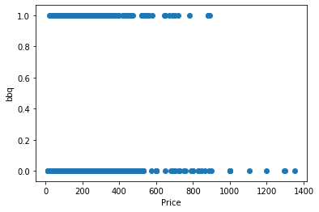

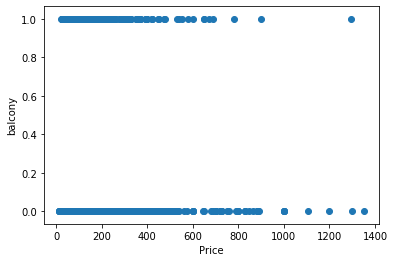

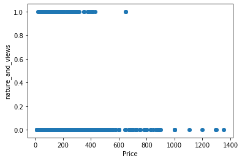

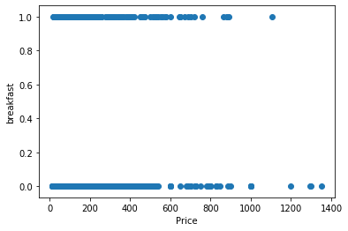

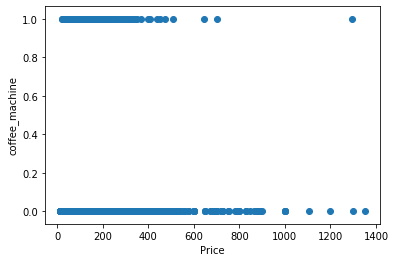

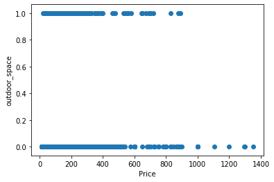

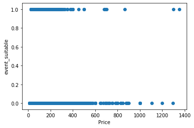

```python
#Lets see if the infrequent amenities are actually not contributing to pridicting price

#Here from the below graphs its beter to initially keep these column as they seem to help in predicting the price
for col in infrequent_amenities:
    plt.scatter(y_train['price'],X_train[col])
    plt.xlabel('Price')
    plt.ylabel(col)
    plt.show()
```

```python
y_train['price'].max()
```

```
1350
```

```python
#Replacing NaN values in below categorical variables with their mode

trn_host_response_time=X_train['host_response_time'].mode()[0]
X_train.host_response_time = X_train.host_response_time.replace(np.NaN,trn_host_response_time)

trn_host_is_superhost=X_train['host_is_superhost'].mode()[0]
X_train.host_is_superhost = X_train.host_is_superhost.replace(np.NaN, trn_host_is_superhost)

trn_host_identity_verified=X_train['host_identity_verified'].mode()[0]
X_train.host_identity_verified = X_train.host_identity_verified.replace(np.NaN, trn_host_identity_verified)


X_val.host_response_time = X_val.host_response_time.replace(np.NaN,trn_host_response_time)

X_val.host_is_superhost = X_val.host_is_superhost.replace(np.NaN, trn_host_is_superhost)

X_val.host_identity_verified = X_val.host_identity_verified.replace(np.NaN, trn_host_identity_verified)
```

```python
X_train.shape,y_train.shape
```

```
((5277, 53), (5277, 1))
```

```python
X_train,y_train=preprocess_train(X_train,y_train)
```

```python
X_train.shape,y_train.shape
```

```
((5277, 53), (5277, 1))
```

```python
X_train.isnull().sum().sum()
```

```
0
```

```python
X_train.head()
```

|  | host_response_time | host_is_superhost | host_identity_verified | neighbourhood_group | latitude | longitude | is_location_exact | property_type | room_type | accommodates | ... | host_greeting | hot_water | internet | long_term_stays | pets_allowed | private_entrance | secure | self_check_in | smoking_allowed | event_suitable |
| --- | --- | --- | --- | --- | --- | --- | --- | --- | --- | --- | --- | --- | --- | --- | --- | --- | --- | --- | --- | --- | --- |
| 3511 | within an hour | 1 | 0 | Central Region | 1.26983 | 103.81331 | 1 | Apartment | Entire home/apt | 6 | ... | 1 | 1 | 1 | 1 | 0 | 1 | 0 | 0 | 0 | 0 |
| 1316 | within a day | 0 | 1 | Central Region | 1.30474 | 103.78763 | 1 | Apartment | Entire home/apt | 4 | ... | 1 | 1 | 1 | 1 | 0 | 0 | 0 | 0 | 0 | 0 |
| 799 | within a day | 0 | 0 | Central Region | 1.28042 | 103.85198 | 1 | Other | Entire home/apt | 1 | ... | 0 | 0 | 1 | 0 | 0 | 0 | 0 | 1 | 0 | 0 |
| 1344 | within an hour | 1 | 0 | North-East Region | 1.40225 | 103.90988 | 0 | Apartment | Private room | 1 | ... | 0 | 0 | 1 | 0 | 0 | 0 | 0 | 1 | 0 | 0 |
| 2864 | within an hour | 0 | 0 | Central Region | 1.31391 | 103.89261 | 1 | Apartment | Private room | 2 | ... | 0 | 1 | 1 | 0 | 1 | 0 | 0 | 0 | 0 | 0 |

5 rows × 53 columns

```python
y_train.head()
```

|  | price |
| --- | --- |
| 3511 | 5.707110 |
| 1316 | 5.303305 |
| 799 | 4.795791 |
| 1344 | 4.007333 |
| 2864 | 3.555348 |

```python
X_val.shape,y_val.shape
```

```
((1333, 53), (1333, 1))
```

```python
X_val,y_val=preprocess_test(X_train,X_val,y_val)
```

```python
X_val.shape,y_val.shape
```

```
((1333, 53), (1333, 1))
```

```python
X_val.isnull().sum().sum()
```

```
0
```

```python
X_val.head()
```

|  | host_response_time | host_is_superhost | host_identity_verified | neighbourhood_group | latitude | longitude | is_location_exact | property_type | room_type | accommodates | ... | host_greeting | hot_water | internet | long_term_stays | pets_allowed | private_entrance | secure | self_check_in | smoking_allowed | event_suitable |
| --- | --- | --- | --- | --- | --- | --- | --- | --- | --- | --- | --- | --- | --- | --- | --- | --- | --- | --- | --- | --- | --- |
| 4305 | within an hour | 1 | 0 | Central Region | 1.31772 | 103.82755 | 1 | Apartment | Hotel room | 3 | ... | 0 | 1 | 1 | 1 | 0 | 0 | 1 | 1 | 0 | 0 |
| 3768 | within a few hours | 0 | 0 | Central Region | 1.31628 | 103.85807 | 1 | Apartment | Entire home/apt | 3 | ... | 0 | 1 | 1 | 1 | 0 | 0 | 0 | 0 | 0 | 0 |
| 4544 | within a few hours | 0 | 0 | East Region | 1.34392 | 103.95853 | 0 | Apartment | Private room | 2 | ... | 1 | 1 | 1 | 0 | 0 | 0 | 0 | 0 | 0 | 0 |
| 7177 | within a few hours | 0 | 0 | West Region | 1.35447 | 103.76829 | 1 | Apartment | Private room | 2 | ... | 1 | 1 | 1 | 1 | 0 | 0 | 0 | 0 | 0 | 0 |
| 6384 | within a few hours | 0 | 0 | Central Region | 1.29946 | 103.85140 | 1 | Apartment | Entire home/apt | 6 | ... | 0 | 0 | 1 | 1 | 0 | 0 | 0 | 0 | 0 | 0 |

5 rows × 53 columns

```python
y_val.head()
```

|  | price |
| --- | --- |
| 4305 | 5.484797 |
| 3768 | 4.709530 |
| 4544 | 4.127134 |
| 7177 | 4.077537 |
| 6384 | 5.342334 |

```python
get_levels_NaNs_combined_info(X_train,len(X_train))
```

|  | Data Type | No of Levels | % of Unique Levels | Levels | Total Cnt of NaN | Total % of NaN |
| --- | --- | --- | --- | --- | --- | --- |
| accommodates | int64 | 12 | 0.227402 | [6 4 1 2 5 8 9 3 7 12 11 10] | 0 | 0.0 |
| air_conditioning | int64 | 2 | 0.037900 | [1 0] | 0 | 0.0 |
| amenities | int64 | 67 | 1.269661 | [34 26 21 14 13 12 20 35 15 29 52 27 16 37 33 ... | 0 | 0.0 |
| balcony | int64 | 2 | 0.037900 | [0 1] | 0 | 0.0 |
| bathrooms | float64 | 13 | 0.246352 | [2.0 1.0 1.5 3.0 4.0 2.5 5.0 0.0 6.0 0.5 3.5 4... | 0 | 0.0 |
| bbq | int64 | 2 | 0.037900 | [0 1] | 0 | 0.0 |
| bed_linen | int64 | 2 | 0.037900 | [1 0] | 0 | 0.0 |
| bed_type | int32 | 2 | 0.037900 | [0 1] | 0 | 0.0 |
| bedrooms | float64 | 6 | 0.113701 | [2.0 1.0 0.0 3.0 5.0 4.0] | 0 | 0.0 |
| beds | float64 | 10 | 0.189502 | [2.0 1.0 3.0 4.0 6.0 0.0 5.0 8.0 7.0 9.0] | 0 | 0.0 |
| breakfast | int64 | 2 | 0.037900 | [0 1] | 0 | 0.0 |
| calculated_host_listings_count | int64 | 52 | 0.985408 | [1 42 2 5 23 43 7 84 19 126 16 4 8 38 159 15 7... | 0 | 0.0 |
| cancellation_policy | object | 3 | 0.056850 | ['strict' 'flexible' 'moderate'] | 0 | 0.0 |
| check_in_24h | int64 | 2 | 0.037900 | [0 1] | 0 | 0.0 |
| child_friendly | int64 | 2 | 0.037900 | [1 0] | 0 | 0.0 |
| cleaning_fee | float64 | 96 | 1.819215 | [60.0 80.0 20.0 0.0 70.0 13.0 100.0 35.0 30.0 ... | 0 | 0.0 |
| coffee_machine | int64 | 2 | 0.037900 | [0 1] | 0 | 0.0 |
| cooking_basics | int64 | 2 | 0.037900 | [1 0] | 0 | 0.0 |
| elevator | int64 | 2 | 0.037900 | [1 0] | 0 | 0.0 |
| event_suitable | int64 | 2 | 0.037900 | [0 1] | 0 | 0.0 |
| extra_people | int64 | 55 | 1.042259 | [40 0 50 21 10 20 42 7 29 22 39 35 41 15 30 45... | 0 | 0.0 |
| guests_included | int64 | 7 | 0.132651 | [4 1 2 3 6 5 7] | 0 | 0.0 |
| gym | int64 | 2 | 0.037900 | [1 0] | 0 | 0.0 |
| host_days_active | float64 | 1347 | 25.525867 | [635.0 1331.0 1641.0 ... 2013.0 2047.0 1901.0] | 0 | 0.0 |
| host_greeting | int64 | 2 | 0.037900 | [1 0] | 0 | 0.0 |
| host_identity_verified | int64 | 2 | 0.037900 | [0 1] | 0 | 0.0 |
| host_is_superhost | int64 | 2 | 0.037900 | [1 0] | 0 | 0.0 |
| host_response_time | object | 4 | 0.075801 | ['within an hour' 'within a day' 'a few days o... | 0 | 0.0 |
| hot_water | int64 | 2 | 0.037900 | [1 0] | 0 | 0.0 |
| instant_bookable | int64 | 2 | 0.037900 | [0 1] | 0 | 0.0 |
| internet | int64 | 2 | 0.037900 | [1 0] | 0 | 0.0 |
| is_location_exact | int64 | 2 | 0.037900 | [1 0] | 0 | 0.0 |
| latitude | float64 | 3653 | 69.224938 | [1.26983 1.30474 1.2804200000000001 ... 1.3349... | 0 | 0.0 |
| long_term_stays | int64 | 2 | 0.037900 | [1 0] | 0 | 0.0 |
| longitude | float64 | 4034 | 76.444950 | [103.81331 103.78763000000001 103.851980000000... | 0 | 0.0 |
| maximum_nights | int64 | 102 | 1.932916 | [90 1124 360 1125 180 365 399 400 31 27 160 15... | 0 | 0.0 |
| minimum_nights | int64 | 52 | 0.985408 | [3 60 2 90 18 7 1 5 20 4 14 6 28 29 30 89 10 2... | 0 | 0.0 |
| nature_and_views | int64 | 2 | 0.037900 | [0 1] | 0 | 0.0 |
| neighbourhood_group | object | 5 | 0.094751 | ['Central Region' 'North-East Region' 'East Re... | 0 | 0.0 |
| outdoor_space | int64 | 2 | 0.037900 | [0 1] | 0 | 0.0 |
| parking | int64 | 2 | 0.037900 | [1 0] | 0 | 0.0 |
| pets_allowed | int64 | 2 | 0.037900 | [0 1] | 0 | 0.0 |
| private_entrance | int64 | 2 | 0.037900 | [1 0] | 0 | 0.0 |
| property_type | object | 3 | 0.056850 | ['Apartment' 'Other' 'House'] | 0 | 0.0 |
| require_guest_phone_verification | int64 | 2 | 0.037900 | [0 1] | 0 | 0.0 |
| require_guest_profile_picture | int64 | 2 | 0.037900 | [0 1] | 0 | 0.0 |
| room_type | object | 4 | 0.075801 | ['Entire home/apt' 'Private room' 'Hotel room'... | 0 | 0.0 |
| secure | int64 | 2 | 0.037900 | [0 1] | 0 | 0.0 |
| security_deposit | float64 | 191 | 3.619481 | [300.0 200.0 150.0 201.0 143.0 0.0 385.0 235.0... | 0 | 0.0 |
| self_check_in | int64 | 2 | 0.037900 | [0 1] | 0 | 0.0 |
| smoking_allowed | int64 | 2 | 0.037900 | [0 1] | 0 | 0.0 |
| tv | int64 | 2 | 0.037900 | [1 0] | 0 | 0.0 |
| white_goods | int64 | 2 | 0.037900 | [1 0] | 0 | 0.0 |

```python
#Creating Dummies for the Categorical columns
X_train = pd.get_dummies(X_train)
X_val = pd.get_dummies(X_val)
```

```python
X_train.shape,y_train.shape,X_val.shape,y_val.shape
```

```
((5277, 67), (5277, 1), (1333, 67), (1333, 1))
```

```python
X_train, X_val = X_train.align(X_val, join='outer', axis=1, fill_value=0)
X_train.shape,y_train.shape,X_val.shape,y_val.shape
```

```
((5277, 67), (5277, 1), (1333, 67), (1333, 1))
```

```python
get_levels_NaNs_combined_info(X_train,len(X_train))
```

|  | Data Type | No of Levels | % of Unique Levels | Levels | Total Cnt of NaN | Total % of NaN |
| --- | --- | --- | --- | --- | --- | --- |
| accommodates | int64 | 12 | 0.227402 | [ 6. 4. 1. 2. 5. 8. 9. 3. 7. 12. 11. 10.] | 0 | 0.0 |
| air_conditioning | int64 | 2 | 0.037900 | [1. 0.] | 0 | 0.0 |
| amenities | int64 | 67 | 1.269661 | [34. 26. 21. 14. 13. 12. 20. 35. 15. 29. 52. 2... | 0 | 0.0 |
| balcony | int64 | 2 | 0.037900 | [0. 1.] | 0 | 0.0 |
| bathrooms | float64 | 13 | 0.246352 | [2. 1. 1.5 3. 4. 2.5 5. 0. 6. 0.5 3.5 4... | 0 | 0.0 |
| bbq | int64 | 2 | 0.037900 | [0. 1.] | 0 | 0.0 |
| bed_linen | int64 | 2 | 0.037900 | [1. 0.] | 0 | 0.0 |
| bed_type | int32 | 2 | 0.037900 | [0. 1.] | 0 | 0.0 |
| bedrooms | float64 | 6 | 0.113701 | [2. 1. 0. 3. 5. 4.] | 0 | 0.0 |
| beds | float64 | 10 | 0.189502 | [2. 1. 3. 4. 6. 0. 5. 8. 7. 9.] | 0 | 0.0 |
| breakfast | int64 | 2 | 0.037900 | [0. 1.] | 0 | 0.0 |
| calculated_host_listings_count | int64 | 52 | 0.985408 | [ 1. 42. 2. 5. 23. 43. 7. 84. 19. ... | 0 | 0.0 |
| cancellation_policy_flexible | uint8 | 2 | 0.037900 | [0. 1.] | 0 | 0.0 |
| cancellation_policy_moderate | uint8 | 2 | 0.037900 | [0. 1.] | 0 | 0.0 |
| cancellation_policy_strict | uint8 | 2 | 0.037900 | [1. 0.] | 0 | 0.0 |
| check_in_24h | int64 | 2 | 0.037900 | [0. 1.] | 0 | 0.0 |
| child_friendly | int64 | 2 | 0.037900 | [1. 0.] | 0 | 0.0 |
| cleaning_fee | float64 | 96 | 1.819215 | [ 60. 80. 20. 0. 70. 13. 100. 35. 30. ... | 0 | 0.0 |
| coffee_machine | int64 | 2 | 0.037900 | [0. 1.] | 0 | 0.0 |
| cooking_basics | int64 | 2 | 0.037900 | [1. 0.] | 0 | 0.0 |
| elevator | int64 | 2 | 0.037900 | [1. 0.] | 0 | 0.0 |
| event_suitable | int64 | 2 | 0.037900 | [0. 1.] | 0 | 0.0 |
| extra_people | int64 | 55 | 1.042259 | [40. 0. 50. 21. 10. 20. 42. 7. 29. 22. 39. 3... | 0 | 0.0 |
| guests_included | int64 | 7 | 0.132651 | [4. 1. 2. 3. 6. 5. 7.] | 0 | 0.0 |
| gym | int64 | 2 | 0.037900 | [1. 0.] | 0 | 0.0 |
| host_days_active | float64 | 1347 | 25.525867 | [ 635. 1331. 1641. ... 2013. 2047. 1901.] | 0 | 0.0 |
| host_greeting | int64 | 2 | 0.037900 | [1. 0.] | 0 | 0.0 |
| host_identity_verified | int64 | 2 | 0.037900 | [0. 1.] | 0 | 0.0 |
| host_is_superhost | int64 | 2 | 0.037900 | [1. 0.] | 0 | 0.0 |
| host_response_time_a few days or more | uint8 | 2 | 0.037900 | [0. 1.] | 0 | 0.0 |
| host_response_time_within a day | uint8 | 2 | 0.037900 | [0. 1.] | 0 | 0.0 |
| host_response_time_within a few hours | uint8 | 2 | 0.037900 | [0. 1.] | 0 | 0.0 |
| host_response_time_within an hour | uint8 | 2 | 0.037900 | [1. 0.] | 0 | 0.0 |
| hot_water | int64 | 2 | 0.037900 | [1. 0.] | 0 | 0.0 |
| instant_bookable | int64 | 2 | 0.037900 | [0. 1.] | 0 | 0.0 |
| internet | int64 | 2 | 0.037900 | [1. 0.] | 0 | 0.0 |
| is_location_exact | int64 | 2 | 0.037900 | [1. 0.] | 0 | 0.0 |
| latitude | float64 | 3653 | 69.224938 | [1.26983 1.30474 1.28042 ... 1.33496 1.34985 1... | 0 | 0.0 |
| long_term_stays | int64 | 2 | 0.037900 | [1. 0.] | 0 | 0.0 |
| longitude | float64 | 4034 | 76.444950 | [103.81331 103.78763 103.85198 ... 103.87271 1... | 0 | 0.0 |
| maximum_nights | int64 | 102 | 1.932916 | [9.000e+01 1.124e+03 3.600e+02 1.125e+03 1.800... | 0 | 0.0 |
| minimum_nights | int64 | 52 | 0.985408 | [ 3. 60. 2. 90. 18. 7. 1. 5. 20. ... | 0 | 0.0 |
| nature_and_views | int64 | 2 | 0.037900 | [0. 1.] | 0 | 0.0 |
| neighbourhood_group_Central Region | uint8 | 2 | 0.037900 | [1. 0.] | 0 | 0.0 |
| neighbourhood_group_East Region | uint8 | 2 | 0.037900 | [0. 1.] | 0 | 0.0 |
| neighbourhood_group_North Region | uint8 | 2 | 0.037900 | [0. 1.] | 0 | 0.0 |
| neighbourhood_group_North-East Region | uint8 | 2 | 0.037900 | [0. 1.] | 0 | 0.0 |
| neighbourhood_group_West Region | uint8 | 2 | 0.037900 | [0. 1.] | 0 | 0.0 |
| outdoor_space | int64 | 2 | 0.037900 | [0. 1.] | 0 | 0.0 |
| parking | int64 | 2 | 0.037900 | [1. 0.] | 0 | 0.0 |
| pets_allowed | int64 | 2 | 0.037900 | [0. 1.] | 0 | 0.0 |
| private_entrance | int64 | 2 | 0.037900 | [1. 0.] | 0 | 0.0 |
| property_type_Apartment | uint8 | 2 | 0.037900 | [1. 0.] | 0 | 0.0 |
| property_type_House | uint8 | 2 | 0.037900 | [0. 1.] | 0 | 0.0 |
| property_type_Other | uint8 | 2 | 0.037900 | [0. 1.] | 0 | 0.0 |
| require_guest_phone_verification | int64 | 2 | 0.037900 | [0. 1.] | 0 | 0.0 |
| require_guest_profile_picture | int64 | 2 | 0.037900 | [0. 1.] | 0 | 0.0 |
| room_type_Entire home/apt | uint8 | 2 | 0.037900 | [1. 0.] | 0 | 0.0 |
| room_type_Hotel room | uint8 | 2 | 0.037900 | [0. 1.] | 0 | 0.0 |
| room_type_Private room | uint8 | 2 | 0.037900 | [0. 1.] | 0 | 0.0 |
| room_type_Shared room | uint8 | 2 | 0.037900 | [0. 1.] | 0 | 0.0 |
| secure | int64 | 2 | 0.037900 | [0. 1.] | 0 | 0.0 |
| security_deposit | float64 | 191 | 3.619481 | [ 300. 200. 150. 201. 143. 0. 385. 23... | 0 | 0.0 |
| self_check_in | int64 | 2 | 0.037900 | [0. 1.] | 0 | 0.0 |
| smoking_allowed | int64 | 2 | 0.037900 | [0. 1.] | 0 | 0.0 |
| tv | int64 | 2 | 0.037900 | [1. 0.] | 0 | 0.0 |
| white_goods | int64 | 2 | 0.037900 | [1. 0.] | 0 | 0.0 |

```python
#get_heatmap(X_train.merge(y_train,left_index=True,right_index=True))
```

```python
#Checking for Multi Collinearity
vif = pd.DataFrame()
vif["features"] = X_train.columns
vif["VIF Factor"] = [variance_inflation_factor(X_train.values, i) for i in range(X_train.shape[1])]
```

```python
vif.sort_values('VIF Factor',ascending=False)
```

|  | features | VIF Factor |
| --- | --- | --- |
| 66 | cancellation_policy_strict | inf |
| 60 | room_type_Entire home/apt | inf |
| 48 | host_response_time_a few days or more | inf |
| 49 | host_response_time_within a day | inf |
| 50 | host_response_time_within a few hours | inf |
| 51 | host_response_time_within an hour | inf |
| 52 | neighbourhood_group_Central Region | inf |
| 53 | neighbourhood_group_East Region | inf |
| 54 | neighbourhood_group_North Region | inf |
| 55 | neighbourhood_group_North-East Region | inf |
| 56 | neighbourhood_group_West Region | inf |
| 57 | property_type_Apartment | inf |
| 59 | property_type_Other | inf |
| 58 | property_type_House | inf |
| 64 | cancellation_policy_flexible | inf |
| 62 | room_type_Private room | inf |
| 65 | cancellation_policy_moderate | inf |
| 63 | room_type_Shared room | inf |
| 61 | room_type_Hotel room | inf |
| 10 | amenities | 6.033448 |
| 19 | require_guest_phone_verification | 5.347852 |
| 5 | accommodates | 5.240790 |
| 18 | require_guest_profile_picture | 5.236121 |
| 3 | longitude | 3.740135 |
| 13 | guests_included | 3.230849 |
| 8 | beds | 2.835249 |
| 2 | latitude | 2.637727 |
| 7 | bedrooms | 2.526594 |
| 41 | long_term_stays | 2.339844 |
| 31 | cooking_basics | 2.155539 |
| 27 | bed_linen | 2.080314 |
| 20 | calculated_host_listings_count | 2.076623 |
| 39 | hot_water | 1.815262 |
| 33 | elevator | 1.774980 |
| 45 | self_check_in | 1.668458 |
| 34 | gym | 1.645443 |
| 21 | host_days_active | 1.576328 |
| 6 | bathrooms | 1.575803 |
| 42 | pets_allowed | 1.553376 |
| 12 | cleaning_fee | 1.545544 |
| 14 | extra_people | 1.522114 |
| 38 | host_greeting | 1.481472 |
| 25 | balcony | 1.478255 |
| 44 | secure | 1.440439 |
| 29 | tv | 1.424528 |
| 24 | bbq | 1.413303 |
| 11 | security_deposit | 1.383723 |
| 17 | instant_bookable | 1.354637 |
| 35 | child_friendly | 1.351595 |
| 43 | private_entrance | 1.341850 |
| 23 | air_conditioning | 1.336133 |
| 1 | host_identity_verified | 1.307630 |
| 32 | white_goods | 1.306436 |
| 40 | internet | 1.302267 |
| 37 | outdoor_space | 1.290597 |
| 30 | coffee_machine | 1.287507 |
| 0 | host_is_superhost | 1.243019 |
| 22 | check_in_24h | 1.220858 |
| 46 | smoking_allowed | 1.217383 |
| 36 | parking | 1.214675 |
| 28 | breakfast | 1.214594 |
| 15 | minimum_nights | 1.180891 |
| 26 | nature_and_views | 1.172443 |
| 47 | event_suitable | 1.124403 |
| 16 | maximum_nights | 1.099587 |
| 4 | is_location_exact | 1.066762 |
| 9 | bed_type | 1.042346 |

```python
#Considering columns with VIF value greater than 3.7 as highly multicollinear
vif[(vif['VIF Factor']>3.7) & (vif['VIF Factor']!=np.inf)]
```

|  | features | VIF Factor |
| --- | --- | --- |
| 3 | longitude | 3.740135 |
| 5 | accommodates | 5.240790 |
| 10 | amenities | 6.033448 |
| 18 | require_guest_profile_picture | 5.236121 |
| 19 | require_guest_phone_verification | 5.347852 |

```python
#Taking highly multi collinear features
drop_cols=vif[(vif['VIF Factor']>3.7) & (vif['VIF Factor']!=np.inf)]['features'].values
```

```python
X_train.drop(drop_cols, axis=1, inplace=True)
X_val.drop(drop_cols, axis=1, inplace=True)
```

```python
X_train.shape,y_train.shape,X_val.shape,y_val.shape
```

```
((5277, 62), (5277, 1), (1333, 62), (1333, 1))
```

```python
#Thruugh Grid Search CV trying to find best Param, estimators
lasso=Lasso()
parameters={'alpha':[1e-15,1e-10,1e-8,1e-4,1e-3,1e-12,1,5,10,20]}
lasso_regress=GridSearchCV(lasso,parameters,cv=5)
lasso_regress.fit(X_train,y_train)
```

```
GridSearchCV(cv=5, error_score='raise-deprecating',
             estimator=Lasso(alpha=1.0, copy_X=True, fit_intercept=True,
                             max_iter=1000, normalize=False, positive=False,
                             precompute=False, random_state=None,
                             selection='cyclic', tol=0.0001, warm_start=False),
             iid='warn', n_jobs=None,
             param_grid={'alpha': [1e-15, 1e-10, 1e-08, 0.0001, 0.001, 1e-12, 1,
                                   5, 10, 20]},
             pre_dispatch='2*n_jobs', refit=True, return_train_score=False,
             scoring=None, verbose=0)
```

```python
lasso_regress.best_params_
```

```
{'alpha': 1e-08}
```

```python
lasso_regress.best_estimator_
```

```
Lasso(alpha=1e-08, copy_X=True, fit_intercept=True, max_iter=1000,
      normalize=False, positive=False, precompute=False, random_state=None,
      selection='cyclic', tol=0.0001, warm_start=False)
```

```python
lasso=Lasso(alpha=1e-08, copy_X=True, fit_intercept=True, max_iter=1000,
      normalize=False, positive=False, precompute=False, random_state=None,
      selection='cyclic', tol=0.0001, warm_start=False)
```

```python
lasso_regress.fit(X_train,y_train)
```

```
GridSearchCV(cv=5, error_score='raise-deprecating',
             estimator=Lasso(alpha=1.0, copy_X=True, fit_intercept=True,
                             max_iter=1000, normalize=False, positive=False,
                             precompute=False, random_state=None,
                             selection='cyclic', tol=0.0001, warm_start=False),
             iid='warn', n_jobs=None,
             param_grid={'alpha': [1e-15, 1e-10, 1e-08, 0.0001, 0.001, 1e-12, 1,
                                   5, 10, 20]},
             pre_dispatch='2*n_jobs', refit=True, return_train_score=False,
             scoring=None, verbose=0)
```

```
---------------------------------------------------------------------------------
Training RMSE of Lasso Regression: 82.25594800795527
Testing RMSE of Lasso Regression : 212.38884369518308
Lasso Best Parameter: {'alpha': 1e-08}
```

```
([0.1412601053290644,
  0.14755036745886135,
  0.16596610073226734,
  0.16695485528109807,
  0.16439000378901641,
  0.16686421867311418,
  0.1689050890007443,
  0.17126671624425355,
  0.17431535198353404,
  0.17575555330334244],
 [0.24502410122628568,
  0.24701755931924657,
  0.2375982506633267,
  0.23660831557069978,
  0.23390729665589008,
  0.23479250352814718,
  0.23450281883073681,
  0.23336343173291718,
  0.2324874864414156,
  0.2316024186103221])
```

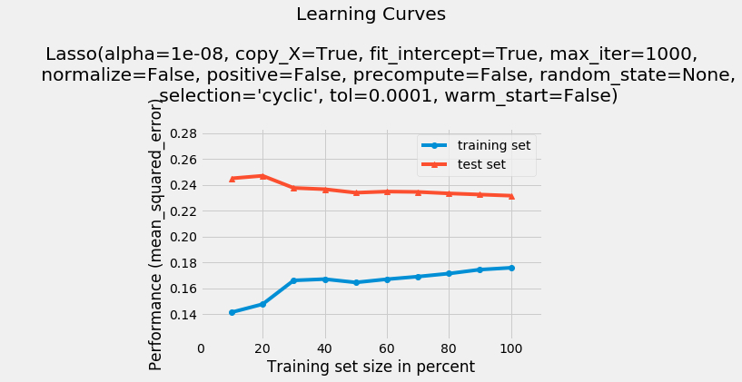

```python
#Performing Lasso regression
y_train_pred_lreg_be = lasso_regress.predict(X_train)
y_val_pred_lreg_be = lasso_regress.predict(X_val)
print("---------------------------------------------------------------------------------")

print("Training RMSE of Lasso Regression:",np.sqrt(mean_squared_error(np.exp(y_train), np.exp(y_train_pred_lreg_be))))
print("Testing RMSE of Lasso Regression :",np.sqrt(mean_squared_error(np.exp(y_val), np.exp(y_val_pred_lreg_be))))

print('Lasso Best Parameter:',lasso_regress.best_params_)

plot_learning_curves(X_train, y_train, X_val, y_val, lasso, scoring='mean_squared_error')
```

```python
# Viewing the coefficients of Lasso Regression to do for dimentionality reduction by penalizing the coefficients that have
#coefficient close to 0
lasso_feature_coef_df=(pd.DataFrame(X_train.columns,columns=['feature']))\
.merge(pd.DataFrame(lasso.coef_,columns=['coef']),left_index=True,right_index=True).sort_values('coef',ascending=False)
lasso_feature_coef_df
```

|  | feature | coef |
| --- | --- | --- |
| 55 | room_type_Entire home/apt | 0.461796 |
| 56 | room_type_Hotel room | 0.350339 |
| 49 | neighbourhood_group_North Region | 0.271953 |
| 7 | bed_type | 0.220840 |
| 24 | tv | 0.160163 |
| 5 | bedrooms | 0.155354 |
| 29 | gym | 0.143201 |
| 53 | property_type_House | 0.115456 |
| 39 | secure | 0.100143 |
| 10 | guests_included | 0.078343 |
| 23 | breakfast | 0.075226 |
| 6 | beds | 0.072514 |
| 28 | elevator | 0.069970 |
| 32 | outdoor_space | 0.069818 |
| 42 | event_suitable | 0.068903 |
| 43 | host_response_time_a few days or more | 0.068632 |
| 37 | pets_allowed | 0.067702 |
| 30 | child_friendly | 0.064798 |
| 0 | host_is_superhost | 0.063259 |
| 59 | cancellation_policy_flexible | 0.059345 |
| 52 | property_type_Apartment | 0.053878 |
| 31 | parking | 0.045560 |
| 26 | cooking_basics | 0.029198 |
| 50 | neighbourhood_group_North-East Region | 0.027202 |
| 19 | bbq | 0.024057 |
| 41 | smoking_allowed | 0.017299 |
| 22 | bed_linen | 0.013988 |
| 36 | long_term_stays | 0.010516 |
| 61 | cancellation_policy_strict | 0.003573 |
| 46 | host_response_time_within an hour | 0.003334 |
| 9 | cleaning_fee | 0.002997 |
| 38 | private_entrance | 0.002242 |
| 15 | calculated_host_listings_count | 0.000187 |
| 11 | extra_people | 0.000091 |
| 8 | security_deposit | 0.000056 |
| 13 | maximum_nights | 0.000030 |
| 16 | host_days_active | -0.000041 |
| 12 | minimum_nights | -0.001396 |
| 3 | is_location_exact | -0.001890 |
| 17 | check_in_24h | -0.005815 |
| 48 | neighbourhood_group_East Region | -0.006466 |
| 40 | self_check_in | -0.009175 |
| 1 | host_identity_verified | -0.011721 |
| 57 | room_type_Private room | -0.011852 |
| 25 | coffee_machine | -0.015507 |
| 44 | host_response_time_within a day | -0.020306 |
| 60 | cancellation_policy_moderate | -0.027522 |
| 54 | property_type_Other | -0.027892 |
| 45 | host_response_time_within a few hours | -0.032113 |
| 34 | hot_water | -0.043033 |
| 51 | neighbourhood_group_West Region | -0.043171 |
| 20 | balcony | -0.045038 |
| 21 | nature_and_views | -0.047296 |
| 14 | instant_bookable | -0.050222 |
| 47 | neighbourhood_group_Central Region | -0.054455 |
| 4 | bathrooms | -0.055513 |
| 33 | host_greeting | -0.065216 |
| 18 | air_conditioning | -0.078428 |
| 35 | internet | -0.080106 |
| 27 | white_goods | -0.264949 |
| 58 | room_type_Shared room | -0.503241 |
| 2 | latitude | -4.273963 |

```python
#Trying to see the features and feature count based on the selection of the threhold for feature selection from feature coef
features_list=[]
for i in np.linspace(start = 0.01, stop = .05, num = 5):
    features_list.\
    append(list(lasso_feature_coef_df[(lasso_feature_coef_df['coef']>i)|(lasso_feature_coef_df['coef']<-i)]['feature']))

    print(lasso_feature_coef_df[(lasso_feature_coef_df['coef']>i)|(lasso_feature_coef_df['coef']<-i)].shape[0],'Features',\
          list(lasso_feature_coef_df[(lasso_feature_coef_df['coef']>i)|(lasso_feature_coef_df['coef']<-i)]['feature']))
    print()
```

```
48 Features ['room_type_Entire home/apt', 'room_type_Hotel room', 'neighbourhood_group_North Region', 'bed_type', 'tv', 'bedrooms', 'gym', 'property_type_House', 'secure', 'guests_included', 'breakfast', 'beds', 'elevator', 'outdoor_space', 'event_suitable', 'host_response_time_a few days or more', …

42 Features ['room_type_Entire home/apt', 'room_type_Hotel room', 'neighbourhood_group_North Region', 'bed_type', 'tv', 'bedrooms', 'gym', 'property_type_House', 'secure', 'guests_included', 'breakfast', 'beds', 'elevator', 'outdoor_space', 'event_suitable', 'host_response_time_a few days or more', …

36 Features ['room_type_Entire home/apt', 'room_type_Hotel room', 'neighbourhood_group_North Region', 'bed_type', 'tv', 'bedrooms', 'gym', 'property_type_House', 'secure', 'guests_included', 'breakfast', 'beds', 'elevator', 'outdoor_space', 'event_suitable', 'host_response_time_a few days or more', …

35 Features ['room_type_Entire home/apt', 'room_type_Hotel room', 'neighbourhood_group_North Region', 'bed_type', 'tv', 'bedrooms', 'gym', 'property_type_House', 'secure', 'guests_included', 'breakfast', 'beds', 'elevator', 'outdoor_space', 'event_suitable', 'host_response_time_a few days or more', …

30 Features ['room_type_Entire home/apt', 'room_type_Hotel room', 'neighbourhood_group_North Region', 'bed_type', 'tv', 'bedrooms', 'gym', 'property_type_House', 'secure', 'guests_included', 'breakfast', 'beds', 'elevator', 'outdoor_space', 'event_suitable', 'host_response_time_a few days or more', …
```

```
=================================================================================
Training RMSE of Linear Regression: 82.25593939870123
Testing RMSE of Linear Regression : 212.38883391518888
```

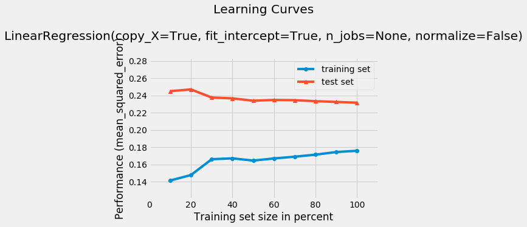

```python
#Multiple Lnear Regression
lm = LinearRegression()
lm.fit(X_train,y_train)
y_train_pred_lm_be = lm.predict(X_train)
y_val_pred_lm_be = lm.predict(X_val)
print("=================================================================================")
print("Training RMSE of Linear Regression:",np.sqrt(mean_squared_error(np.exp(y_train)-1, np.exp(y_train_pred_lm_be)-1)))
print("Testing RMSE of Linear Regression :",np.sqrt(mean_squared_error(np.exp(y_val)-1, np.exp(y_val_pred_lm_be)-1)))

plot_learning_curves(X_train, y_train, X_val, y_val, lm, scoring='mean_squared_error')
plt.show()
```

```python
#Multiple Linear Regression using different set of paramerters set, created from Lasso coefficients
for i in features_list:
    lm = LinearRegression()
    lm.fit(X_train[i],y_train)
    y_train_pred_lm_be = lm.predict(X_train[i])
    y_val_pred_lm_be = lm.predict(X_val[i])
    print("=================================================================================")
    print("No of features used based on Lasso Coef=",len(i))
    print("Training RMSE of Multiple Linear Regression:",np.sqrt(mean_squared_error(np.exp(y_train)-1, np.exp(y_train_pred_lm_be)-1)))
    print("Testing RMSE of Multiple Linear Regression :",np.sqrt(mean_squared_error(np.exp(y_val)-1, np.exp(y_val_pred_lm_be)-1)))
```

```
=================================================================================
No of features used based on Lasso Coef= 48
Training RMSE of Multiple Linear Regression: 83.37922484747679
Testing RMSE of Multiple Linear Regression : 213.87869865483475
=================================================================================
No of features used based on Lasso Coef= 42
Training RMSE of Multiple Linear Regression: 83.956343625511
Testing RMSE of Multiple Linear Regression : 214.25311468936485
=================================================================================
No of features used based on Lasso Coef= 36
Training RMSE of Multiple Linear Regression: 83.67299844271271
Testing RMSE of Multiple Linear Regression : 214.26124626857867
=================================================================================
No of features used based on Lasso Coef= 35
Training RMSE of Multiple Linear Regression: 83.7199279006832
Testing RMSE of Multiple Linear Regression : 214.28476870420405
=================================================================================
No of features used based on Lasso Coef= 30
Training RMSE of Multiple Linear Regression: 83.85493749972173
Testing RMSE of Multiple Linear Regression : 214.19293499413487
```

```python
#Random Forest Regressor using different set of paramerters set, created from Lasso coefficients
for i in features_list:
    rf = RandomForestRegressor(min_samples_leaf=4000)
    rf.fit(X_train[i],y_train)
    y_train_pred_rf_be = rf.predict(X_train[i])
    y_val_pred_rf_be = rf.predict(X_val[i])
    print("---------------------------------------------------------------------------------")
    print("No of features used based on Lasso Coef=",len(i))
    print("Training RMSE of RandomForestRegressor:",np.sqrt(mean_squared_error(np.exp(y_train)-1, np.exp(y_train_pred_rf_be)-1)))
    print("Testing RMSE of RandomForestRegressor :",np.sqrt(mean_squared_error(np.exp(y_val)-1, np.exp(y_val_pred_rf_be)-1)))
```

```
---------------------------------------------------------------------------------
No of features used based on Lasso Coef= 48
Training RMSE of RandomForestRegressor: 120.22015735958503
Testing RMSE of RandomForestRegressor : 229.53127875222674
---------------------------------------------------------------------------------
No of features used based on Lasso Coef= 42
Training RMSE of RandomForestRegressor: 120.16174690576243
Testing RMSE of RandomForestRegressor : 229.49117742191478
---------------------------------------------------------------------------------
No of features used based on Lasso Coef= 36
Training RMSE of RandomForestRegressor: 120.28215677780595
Testing RMSE of RandomForestRegressor : 229.57378744187653
---------------------------------------------------------------------------------
No of features used based on Lasso Coef= 35
Training RMSE of RandomForestRegressor: 120.31917185388352
Testing RMSE of RandomForestRegressor : 229.59913889727846
---------------------------------------------------------------------------------
No of features used based on Lasso Coef= 30
Training RMSE of RandomForestRegressor: 120.26807485788964
Testing RMSE of RandomForestRegressor : 229.56413749266648
```

[output not shown]

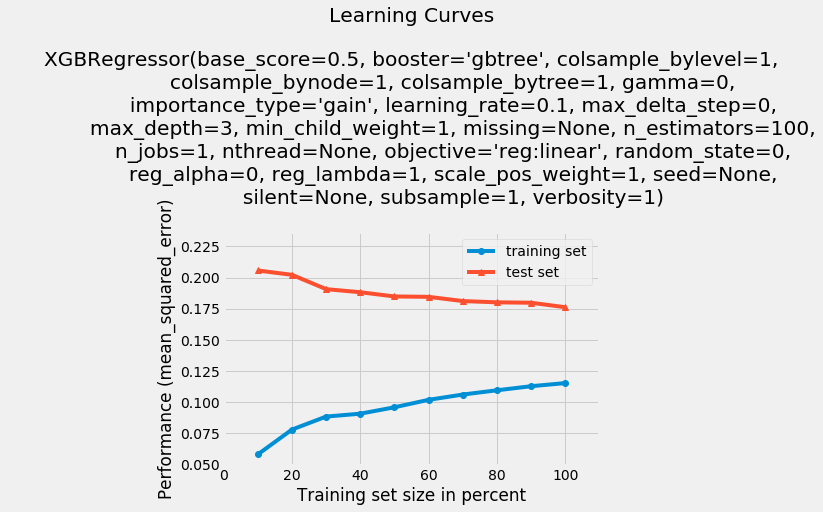

```python
#XGBoost Regressor
xgb=XGBRegressor()
xgb.fit(X_train,y_train)
y_train_pred_xgb = xgb.predict(X_train)
y_val_pred_xgb= xgb.predict(X_val)
print("---------------------------------------------------------------------------------")
print("Training MSE of XGBoost:",np.sqrt(mean_squared_error(np.exp(y_train)-1, np.exp(y_train_pred_xgb)-1)))
print("Testing MSE of XGBoost :",np.sqrt(mean_squared_error(np.exp(y_val)-1, np.exp(y_val_pred_xgb)-1)))

plot_learning_curves(X_train, y_train, X_val, y_val, xgb, scoring='mean_squared_error')
plt.show()
```